# SU_25_River_Rockfish_Proj_Ambient_V0.2

## Which brood condition significantly different (if any)?

Parametric assumptions: - Normality (Shapiro-Wilk test): **Not met** - Variance (Bartletts test): NA

- Nonparametric variance (Levene’s test): **Met**

Differences: Between Fecundity Class

```r
# glucose
# Ambient ANOVA Test

# Testing for differences in ambient parturition success metrics
# One-way ANOVA (parametric) or Kruskal-Wallis test (nonparametric)

glucose_aov_ambient_fec <- aov(Glu..mmol.L. ~ Fecundity_Class, data = Ambient_Samples)
summary(glucose_aov_ambient_fec)
```

```
##                 Df Sum Sq Mean Sq F value Pr(>F)
## Fecundity_Class  2  1.208  0.6041   1.317  0.293
## Residuals       18  8.257  0.4587
```

```r
# If significant, Post Hoc Test:
# - Tukey's HSD (parametric, normality & equal variance across groups)
# - Dunn's test (non-parametric, after Kruskal-Wallis test)

TukeyHSD(glucose_aov_ambient_fec)
```

```
##   Tukey multiple comparisons of means
##     95% family-wise confidence level
##
## Fit: aov(formula = Glu..mmol.L. ~ Fecundity_Class, data = Ambient_Samples)
##
## $Fecundity_Class
##                               diff        lwr      upr     p adj
## Low (~1,000s)-High (>50,000) 0.125 -1.0973103 1.347310 0.9632210
## Atresia-High (>50,000)       0.550 -0.4383693 1.538369 0.3518867
## Atresia-Low (~1,000s)        0.425 -0.5633693 1.413369 0.5277964
```

```r
# Parametric tests

# Normality
shapiro.test(Ambient_Samples$Glu..mmol.L.)
```

```
##
##  Shapiro-Wilk normality test
##
## data:  Ambient_Samples$Glu..mmol.L.
## W = 0.85634, p-value = 0.005473
```

```r
shapiro.test(residuals(aov(Glu..mmol.L. ~ Fecundity_Class, data = Ambient_Samples)))
```

```
##
##  Shapiro-Wilk normality test
##
## data:  residuals(aov(Glu..mmol.L. ~ Fecundity_Class, data = Ambient_Samples))
## W = 0.82056, p-value = 0.001376
```

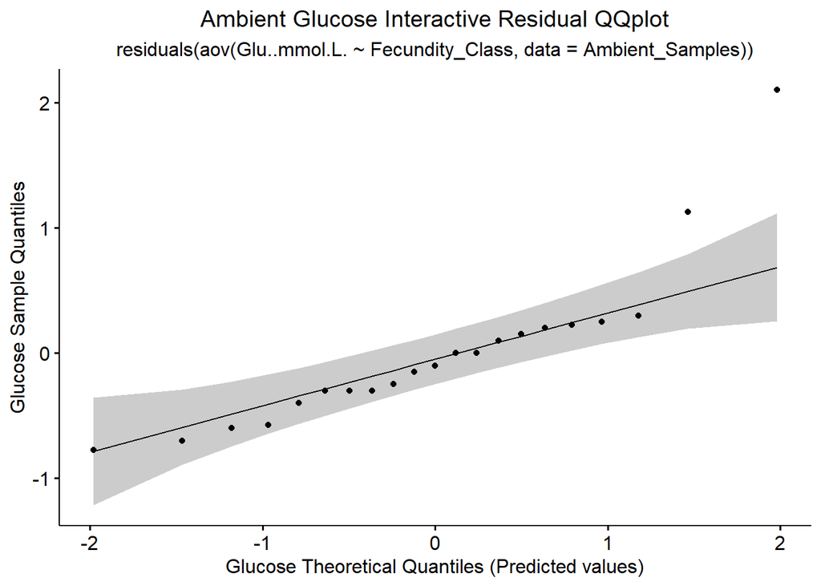

```r
# QQplot:
glucose_ambient_fec_res_qqplot <- ggqqplot(residuals(aov(Glu..mmol.L. ~ Fecundity_Class, data = Ambient_Samples))) +
labs(title = "Ambient Glucose Interactive Residual QQplot",
     subtitle = "residuals(aov(Glu..mmol.L. ~ Fecundity_Class, data = Ambient_Samples))",
                               x = "Glucose Theoretical Quantiles (Predicted values)",
                               y = "Glucose Sample Quantiles") +
  theme(plot.title = element_text(hjust = 0.5),
        plot.subtitle = element_text(hjust = 0.5))
print(glucose_ambient_fec_res_qqplot)
```

```r
# Parametric Variance test (Bartlett's test): require at least 2 obs for each group
bartlett.test(Glu..mmol.L. ~ Fecundity_Class, data = Ambient_Samples)
```

```
##
##  Bartlett test of homogeneity of variances
##
## data:  Glu..mmol.L. by Fecundity_Class
## Bartlett's K-squared = 3.669, df = 2, p-value = 0.1597
```

```r
# Nonparametric variance test (Levene's test):
leveneTest(Glu..mmol.L. ~ Fecundity_Class, data = Ambient_Samples)
```

```
## Levene's Test for Homogeneity of Variance (center = median)
##       Df F value Pr(>F)
## group  2  0.9391 0.4093
##       18
```

```r
# Nonparametric stat test: Kruskall Wallis
kruskal.test(Glu..mmol.L. ~ Fecundity_Class, data = Ambient_Samples)
```

```
##
##  Kruskal-Wallis rank sum test
##
## data:  Glu..mmol.L. by Fecundity_Class
## Kruskal-Wallis chi-squared = 4.0755, df = 2, p-value = 0.1303
```

```r
# Nonparametric Post Hoc: Dunn's test
DunnettTest(Glu..mmol.L. ~ Fecundity_Class, data = Ambient_Samples)
```

```
##
##   Dunnett's test for comparing several treatments with a control :
##     95% family-wise confidence level
##
## $`High (>50,000)`
##                               diff     lwr.ci   upr.ci   pval
## Low (~1,000s)-High (>50,000) 0.125 -1.0137649 1.263765 0.9470
## Atresia-High (>50,000)       0.550 -0.3708139 1.470814 0.2758
##
## ---
## Signif. codes:  0 '***' 0.001 '**' 0.01 '*' 0.05 '.' 0.1 ' ' 1
```

Glucose Ambient Results

## Which fecundity class significantly different (if any)?

Parametric assumptions: - Normality (Shapiro-Wilk test): **Not met** - Variance (Bartlett’s test): **Met**

Nonparametric variance test (Levene’s test): **Met**

Correlations: Parameter to Numerical Fecundity (without Atresia IDs)

```r
# glucose
# Linear Model
glucose_amb_fec_no_atresia_lm <- lm(Glu..mmol.L. ~ Weight_Adjusted_Fecundity_Fecundity.Mean_Weight, data = Fecundity_No_Atresia_Samples)
summary(glucose_amb_fec_no_atresia_lm)
```

```
##
## Call:
## lm(formula = Glu..mmol.L. ~ Weight_Adjusted_Fecundity_Fecundity.Mean_Weight,
##     data = Fecundity_No_Atresia_Samples)
##
## Residuals:
##     Min      1Q  Median      3Q     Max
## -0.8882 -0.5589 -0.3191  0.2610  1.7458
##
## Coefficients:
##                                                 Estimate Std. Error t value
## (Intercept)                                     1.352797   0.563859   2.399
## Weight_Adjusted_Fecundity_Fecundity.Mean_Weight 0.002951   0.002957   0.998
##                                                 Pr(>|t|)
## (Intercept)                                       0.0432 *
## Weight_Adjusted_Fecundity_Fecundity.Mean_Weight   0.3475
## ---
## Signif. codes:  0 '***' 0.001 '**' 0.01 '*' 0.05 '.' 0.1 ' ' 1
##
## Residual standard error: 0.8924 on 8 degrees of freedom
##   (18 observations deleted due to missingness)
## Multiple R-squared:  0.1107, Adjusted R-squared:  -0.0004362
## F-statistic: 0.9961 on 1 and 8 DF,  p-value: 0.3475
```

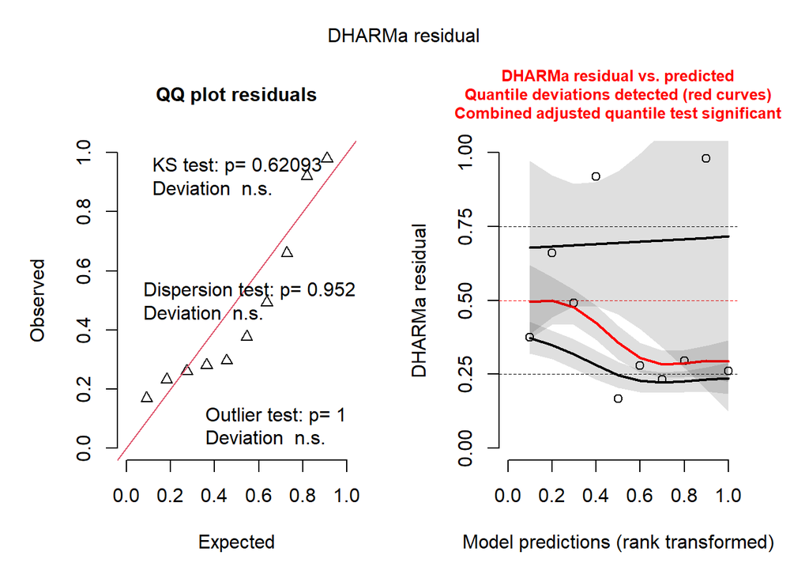

```r
glucose_ambient_sim <- simulateResiduals(fittedModel = glucose_amb_fec_no_atresia_lm)
plot(glucose_ambient_sim)
```

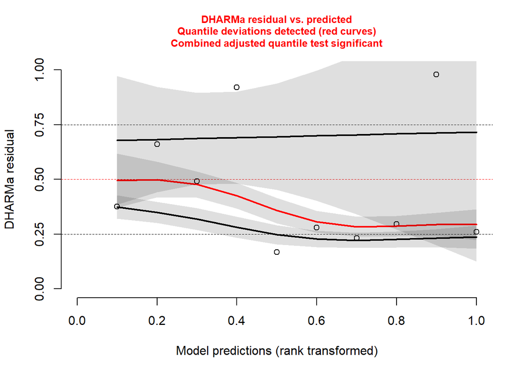

```r
plotResiduals(glucose_amb_fec_no_atresia_lm)
```

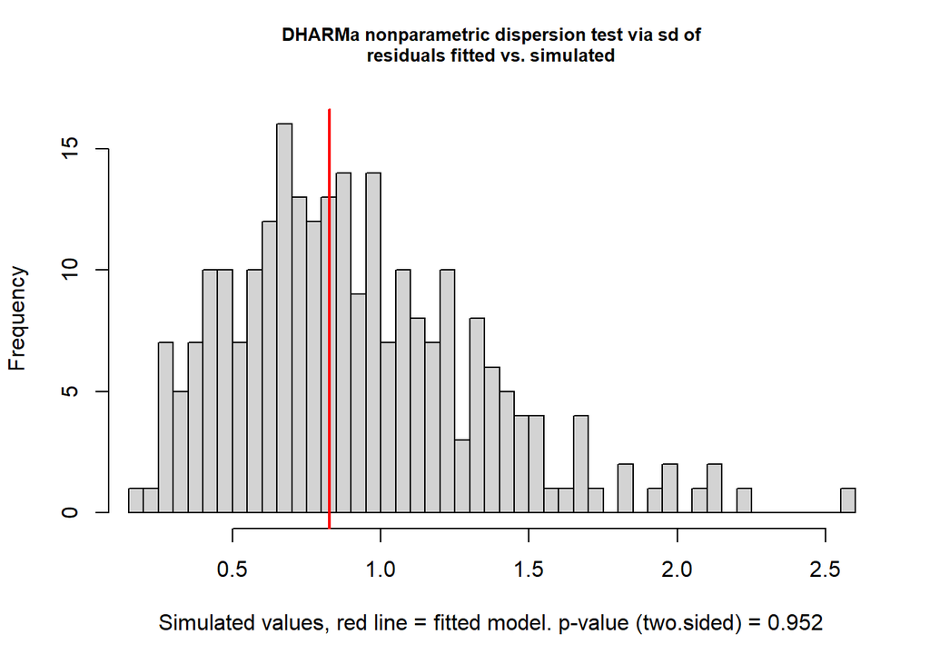

```
##
##  DHARMa nonparametric dispersion test via sd of residuals fitted vs.
##  simulated
##
## data:  simulationOutput
## dispersion = 0.90609, p-value = 0.952
## alternative hypothesis: two.sided
```

```r
testDispersion(glucose_amb_fec_no_atresia_lm)
```

```r
# Normality test:
shapiro.test(residuals(glucose_amb_fec_no_atresia_lm))
```

```
##
##  Shapiro-Wilk normality test
##
## data:  residuals(glucose_amb_fec_no_atresia_lm)
## W = 0.86864, p-value = 0.09638
```

```r
# Transform data: square root
glucose_ambient_sqrt <- Amb_Fec_No_Atresia_Samples %>%
  mutate(Glu..mmol.L. = sqrt(Glu..mmol.L.))

# Rerun lm model with square root transformed data
glucose_amb_fec_no_atresia_lm_sqrt <- lm(Glu..mmol.L. ~ Weight_Adjusted_Fecundity_Fecundity.Mean_Weight, data = glucose_ambient_sqrt)
summary(glucose_amb_fec_no_atresia_lm_sqrt)
```

```
##
## Call:
## lm(formula = Glu..mmol.L. ~ Weight_Adjusted_Fecundity_Fecundity.Mean_Weight,
##     data = glucose_ambient_sqrt)
##
## Residuals:
##      Min       1Q   Median       3Q      Max
## -0.30380 -0.13647 -0.01130  0.07862  0.42723
##
## Coefficients:
##                                                  Estimate Std. Error t value
## (Intercept)                                     1.2241905  0.1551624   7.890
## Weight_Adjusted_Fecundity_Fecundity.Mean_Weight 0.0001917  0.0008838   0.217
##                                                 Pr(>|t|)
## (Intercept)                                      0.00022 ***
## Weight_Adjusted_Fecundity_Fecundity.Mean_Weight  0.83544
## ---
## Signif. codes:  0 '***' 0.001 '**' 0.01 '*' 0.05 '.' 0.1 ' ' 1
##
## Residual standard error: 0.2422 on 6 degrees of freedom
## Multiple R-squared:  0.007783,   Adjusted R-squared:  -0.1576
## F-statistic: 0.04706 on 1 and 6 DF,  p-value: 0.8354
```

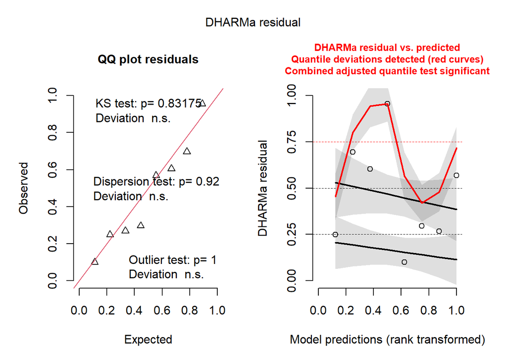

```r
glucose_amb_fec_sqrt_sim <- simulateResiduals(fittedModel = glucose_amb_fec_no_atresia_lm_sqrt)
plot(glucose_amb_fec_sqrt_sim)
```

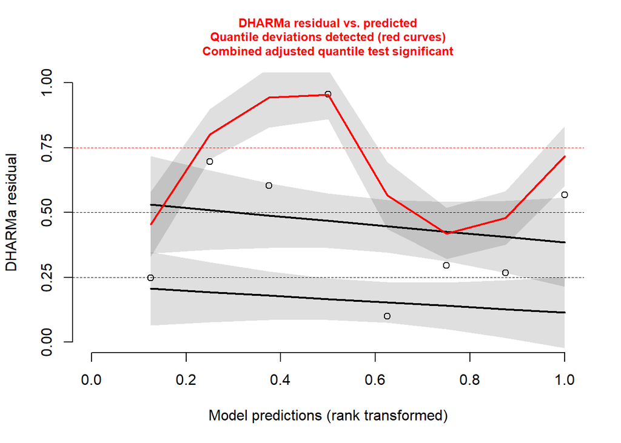

```r
plotResiduals(glucose_amb_fec_no_atresia_lm_sqrt)
```

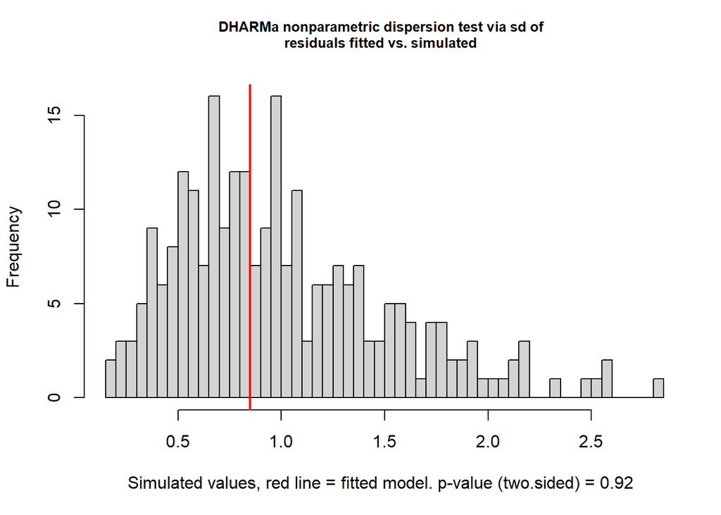

```
##
##  DHARMa nonparametric dispersion test via sd of residuals fitted vs.
##  simulated
##
## data:  simulationOutput
## dispersion = 0.84221, p-value = 0.92
## alternative hypothesis: two.sided
```

```r
testDispersion(glucose_amb_fec_no_atresia_lm_sqrt)
```

```r
# Residuals of model for shapiro test
glucose_amb_fec_no_atresia_lm_res <- residuals(glucose_amb_fec_no_atresia_lm_sqrt)

# Normality test
shapiro.test(glucose_amb_fec_no_atresia_lm_res)
```

```
##
##  Shapiro-Wilk normality test
##
## data:  glucose_amb_fec_no_atresia_lm_res
## W = 0.96004, p-value = 0.8104
```

```r
# Parametric variance test: bartlett's test
# Require at least 2 obs for each group
#bartlett.test(Glu..mmol.L. ~ Weight_Adjusted_Fecundity_Fecundity.Mean_Weight, data = glucose_ambient_sqrt)

# Nonparametric variance test (Levene's test)
# NA for quantitative explanatory variables
# leveneTest(Glu..mmol.L. ~ Weight_Adjusted_Fecundity_Fecundity.Mean_Weight, data = glucose_ambient_sqrt)
```

Glucose Ambient No Atresia Results

## Does a significant correlation exist between weight adj fecundity and parameter?

Parametric assumptions: - Normality (Shapiro-Wilk test): **Met ish** - Variance (Bartlett’s test): NA

Nonparametric variance test (Levene’s test): NA

Residuals Plot (if significant)

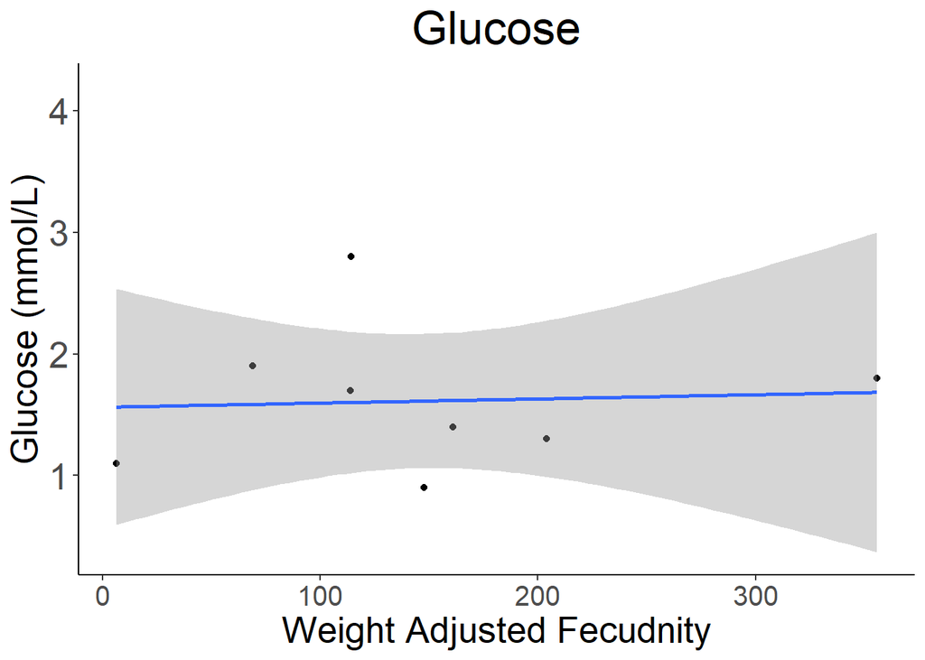

```r
# glucose
# Ambient samples

# ggplot with geom_smooth(aes(x=,y=)), method = "lm")

glucose_ambient_lm_scatterplot <- ggplot(data = Ambient_Samples, aes(x = Weight_Adjusted_Fecundity_Fecundity.Mean_Weight, y = Glu..mmol.L.)) +
  geom_point() +
  geom_smooth(aes(group = 1), method = "lm") +
  labs(title = "Glucose", x = "Weight Adjusted Fecudnity", y = "Glucose (mmol/L)", color = "Category") +
  scale_y_continuous() +
  theme_classic() +
  theme(panel.background = element_rect(fill = "white"),
        plot.background = element_rect(fill = "white"),
        legend.background = element_rect(fill = "white", color = "black"),
        plot.title = element_text(size = 25, hjust = 0.5),
        axis.text.x = element_text(size = 15),
        axis.text.y = element_text(size = 20),
        axis.title.x = element_text(size = 20),
        axis.title.y = element_text(size = 20))

print(glucose_ambient_lm_scatterplot)
```

```r
ggsave(filename = "data-images/glucose_ambient_lm_scatterplot.pdf", plot = glucose_ambient_lm_scatterplot, device = "pdf")
ggsave(filename = "data-images/glucose_ambient_lm_scatterplot.png", plot = glucose_ambient_lm_scatterplot, device = "png")
```

# Na+ : Sodium

Sodium Summary Stats

```r
# sodium
# Summary stats

# Ambient data
Ambient_Samples %>%
  group_by(Ambient.Or.OAH, Consensus_Brood_Condition) %>%
  summarize(count = n(),
            median = round(median(Na...mmol.L.), 3),
            mean = round(mean(Na...mmol.L.), 3),
            sd = round(sd(Na...mmol.L.), 3),
            cv = round(sd(Na...mmol.L.)/mean(Na...mmol.L.), 3)) %>%
  ungroup()
```

```
## # A tibble: 4 × 7
##   Ambient.Or.OAH Consensus_Brood_Condition count median  mean    sd     cv
##   <ord>          <ord>                     <int>  <dbl> <dbl> <dbl>  <dbl>
## 1 Ambient        Excellent                     1   177   177  NA    NA
## 2 Ambient        Normal                        4   178.  177.  2.87  0.016
## 3 Ambient        Low                           3   175   173.  3.79  0.022
## 4 Ambient        Atresia                      13   178   181. 11.4   0.063
```

```r
Ambient_Samples %>%
  group_by(Ambient.Or.OAH, Fecundity_Class) %>%
  summarize(count = n(),
            median = round(median(Na...mmol.L.), 3),
            mean = round(mean(Na...mmol.L.), 3),
            sd = round(sd(Na...mmol.L.), 3),
            cv = round(sd(Na...mmol.L.)/mean(Na...mmol.L.), 3)) %>%
  ungroup()
```

```
## # A tibble: 3 × 7
##   Ambient.Or.OAH Fecundity_Class count median  mean    sd    cv
##   <ord>          <ord>           <int>  <dbl> <dbl> <dbl> <dbl>
## 1 Ambient        High (>50,000)      4   178.  177.  2.63 0.015
## 2 Ambient        Low (~1,000s)       4   176.  175.  4.19 0.024
## 3 Ambient        Atresia            13   178   181. 11.4  0.063
```

```r
Amb_Fec_No_Atresia_Samples %>%
  group_by(Ambient.Or.OAH, Fecundity_Class) %>%
  summarize(count = n(),
            median = round(median(Na...mmol.L.), 3),
            mean = round(mean(Na...mmol.L.), 3),
            sd = round(sd(Na...mmol.L.), 3),
            cv = round(sd(Na...mmol.L.)/mean(Na...mmol.L.), 3)) %>%
  ungroup()
```

```
## # A tibble: 2 × 7
##   Ambient.Or.OAH Fecundity_Class count median  mean    sd    cv
##   <ord>          <ord>           <int>  <dbl> <dbl> <dbl> <dbl>
## 1 Ambient        High (>50,000)      4   178.  177.  2.63 0.015
## 2 Ambient        Low (~1,000s)       4   176.  175.  4.19 0.024
```

Sodium Boxplot

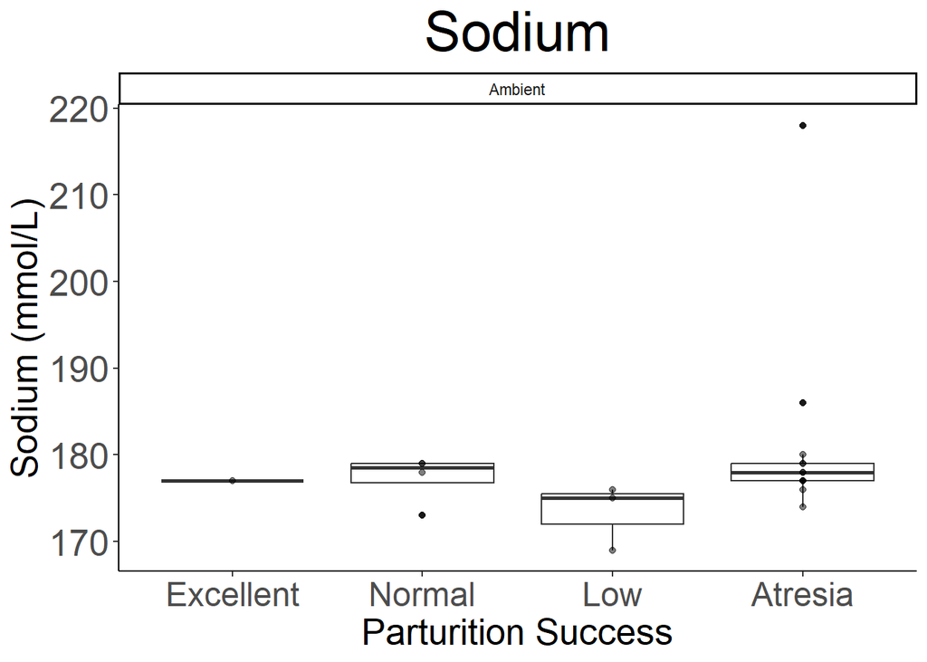

```r
# Na+ boxplot

# Ambient Samples
sodium_ambient_boxplot <- ggplot(data = Ambient_Samples) +
  geom_boxplot(aes(x = Consensus_Brood_Condition, y = Na...mmol.L.)) +
  geom_point(aes(x = Consensus_Brood_Condition, y = Na...mmol.L.), alpha = 0.5, colour = "black") +
  labs(title = "Sodium", x = "Parturition Success", y = "Sodium (mmol/L)") +
  facet_wrap(~ Ambient.Or.OAH) +
  theme_classic() +
  theme(panel.background = element_rect(fill = "white"),
        plot.background = element_rect(fill = "white"),
        legend.background = element_rect(fill = "white", color = "black"),
        title = element_text(size = 12),
        plot.title = element_text(size = 30, hjust = 0.5),
        axis.text.x = element_text(size = 18),
        axis.text.y = element_text(size = 20),
        axis.title.x = element_text(size = 20),
        axis.title.y = element_text(size = 20))

print(sodium_ambient_boxplot)
```

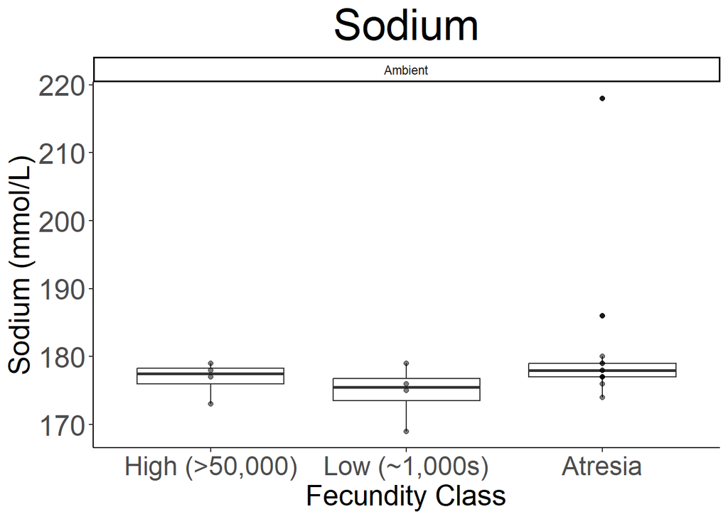

```r
ggsave(filename = "data-images/sodium_ambient_boxplot.pdf", plot = sodium_ambient_boxplot, device = "pdf")
ggsave(filename = "data-images/sodium_ambient_boxplot.png", plot = sodium_ambient_boxplot, device = "png")
sodium_ambient_fecundity_boxplot <- ggplot(data = Ambient_Samples) +
  geom_boxplot(aes(x = Fecundity_Class, y = Na...mmol.L.)) +
  geom_point(aes(x = Fecundity_Class, y = Na...mmol.L.), alpha = 0.5, colour = "black") +
  labs(title = "Sodium", x = "Fecundity Class", y = "Sodium (mmol/L)") +
  facet_wrap(~ Ambient.Or.OAH) +
  theme_classic() +
  theme(panel.background = element_rect(fill = "white"),
        plot.background = element_rect(fill = "white"),
        legend.background = element_rect(fill = "white", color = "black"),
        title = element_text(size = 12),
        plot.title = element_text(size = 30, hjust = 0.5),
        axis.text.x = element_text(size = 18),
        axis.text.y = element_text(size = 20),
        axis.title.x = element_text(size = 20),
        axis.title.y = element_text(size = 20))

print(sodium_ambient_fecundity_boxplot)
```

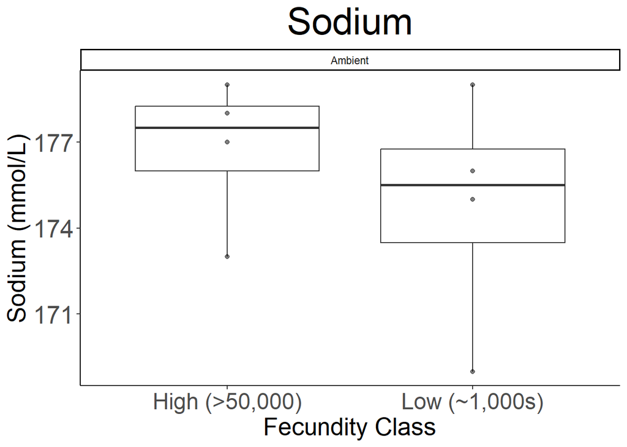

```r
ggsave(filename = "data-images/sodium_ambient_fecundity_boxplot.pdf", plot = sodium_ambient_fecundity_boxplot, device = "pdf")
ggsave(filename = "data-images/sodium_ambient_fecundity_boxplot.png", plot = sodium_ambient_fecundity_boxplot, device = "png")
sodium_amb_fec_no_atresia_boxplot <- ggplot(data = Amb_Fec_No_Atresia_Samples) +
  geom_boxplot(aes(x = Fecundity_Class, y = Na...mmol.L.)) +
  geom_point(aes(x = Fecundity_Class, y = Na...mmol.L.), alpha = 0.5, colour = "black") +
  labs(title = "Sodium", x = "Fecundity Class", y = "Sodium (mmol/L)") +
  facet_wrap(~ Ambient.Or.OAH) +
  theme_classic() +
  theme(panel.background = element_rect(fill = "white"),
        plot.background = element_rect(fill = "white"),
        legend.background = element_rect(fill = "white", color = "black"),
        title = element_text(size = 12),
        plot.title = element_text(size = 30, hjust = 0.5),
        axis.text.x = element_text(size = 18),
        axis.text.y = element_text(size = 20),
        axis.title.x = element_text(size = 20),
        axis.title.y = element_text(size = 20))

print(sodium_amb_fec_no_atresia_boxplot)
```

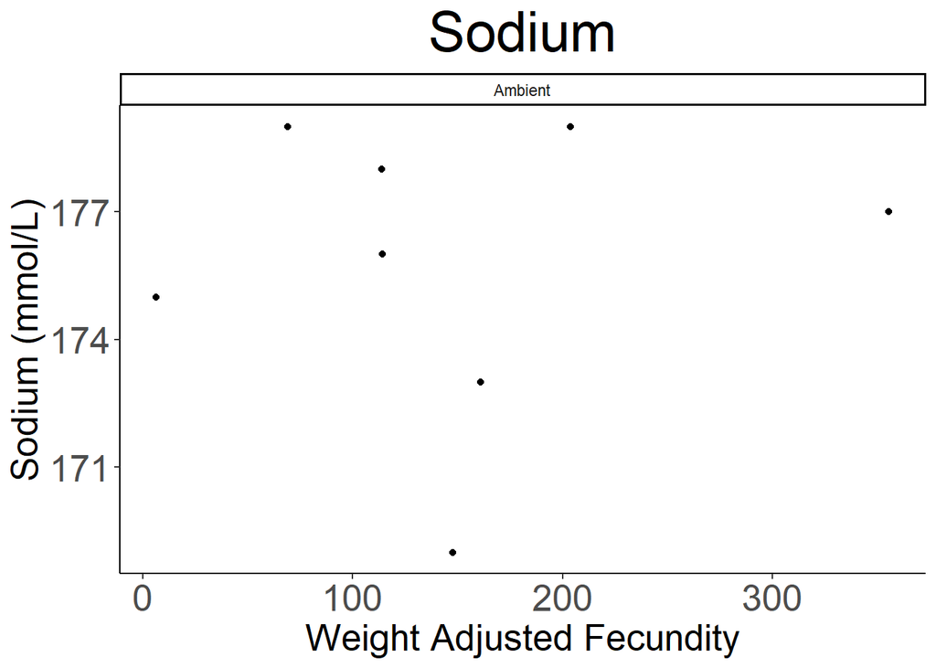

```r
ggsave(filename = "data-images/sodium_amb_fec_no_atresia_boxplot.pdf", plot = sodium_amb_fec_no_atresia_boxplot, device = "pdf")
ggsave(filename = "data-images/sodium_amb_fec_no_atresia_boxplot.png", plot = sodium_amb_fec_no_atresia_boxplot, device = "png")
sodium_amb_fec_no_atresia_scatterplot <- Amb_Fec_No_Atresia_Samples %>%
  ggplot() +
  geom_point(aes(x = Weight_Adjusted_Fecundity_Fecundity.Mean_Weight, y = Na...mmol.L.), colour = "black") +
  labs(title = "Sodium", x = "Weight Adjusted Fecundity", y = "Sodium (mmol/L)") +
  facet_wrap(~ Ambient.Or.OAH) +
  theme_classic() +
  theme(panel.background = element_rect(fill = "white"),
        plot.background = element_rect(fill = "white"),
        legend.background = element_rect(fill = "white", color = "black"),
        title = element_text(size = 12),
        plot.title = element_text(size = 30, hjust = 0.5),
        axis.text.x = element_text(size = 20),
        axis.text.y = element_text(size = 20),
        axis.title.x = element_text(size = 20),
        axis.title.y = element_text(size = 20))

print(sodium_amb_fec_no_atresia_scatterplot)
```

```r
ggsave(filename = "data-images/sodium_amb_fec_no_atresia_scatterplot.pdf", plot = sodium_amb_fec_no_atresia_scatterplot, device = "pdf")
ggsave(filename = "data-images/sodium_amb_fec_no_atresia_scatterplot.pdf", plot = sodium_amb_fec_no_atresia_scatterplot, device = "png")
```

# Na+ Stat Tests

Differences: Between Brood Conditon

```r
# Na+
# Ambient ANOVA Test

# Testing for differences in ambient parturition success metrics
# One-way ANOVA (parametric) or Kruskal-Wallis test (nonparametric)

sodium_aov_ambient_brood <- aov(Na...mmol.L. ~ Consensus_Brood_Condition, data = Ambient_Samples)
summary(sodium_aov_ambient_brood)
```

```
##                           Df Sum Sq Mean Sq F value Pr(>F)
## Consensus_Brood_Condition  3  176.8   58.95   0.622  0.611
## Residuals                 17 1611.7   94.81
```

```r
# If significant, Post Hoc Test:
# - Tukey's HSD (parametric, normality & equal variance across groups)
# - Dunn's test (non-parametric, after Kruskal-Wallis test)

TukeyHSD(sodium_aov_ambient_brood)
```

```
##   Tukey multiple comparisons of means
##     95% family-wise confidence level
##
## Fit: aov(formula = Na...mmol.L. ~ Consensus_Brood_Condition, data = Ambient_Samples)
##
## $Consensus_Brood_Condition
##                        diff        lwr      upr     p adj
## Normal-Excellent   0.250000 -30.694633 31.19463 0.9999955
## Low-Excellent     -3.666667 -35.626146 28.29281 0.9875929
## Atresia-Excellent  4.230769 -24.491760 32.95330 0.9745138
## Low-Normal        -3.916667 -25.055875 17.22254 0.9514394
## Atresia-Normal     3.980769 -11.844573 19.80611 0.8897586
## Atresia-Low        7.897436  -9.830494 25.62537 0.5954090
```

```r
# Parametric tests

# Normality
shapiro.test(Ambient_Samples$Na...mmol.L.)
```

```
##
##  Shapiro-Wilk normality test
##
## data:  Ambient_Samples$Na...mmol.L.
## W = 0.52676, p-value = 3.625e-07
```

```r
shapiro.test(residuals(aov(Na...mmol.L. ~ Consensus_Brood_Condition, data = Ambient_Samples)))
```

```
##
##  Shapiro-Wilk normality test
##
## data:  residuals(aov(Na...mmol.L. ~ Consensus_Brood_Condition, data = Ambient_Samples))
## W = 0.54475, p-value = 5.408e-07
```

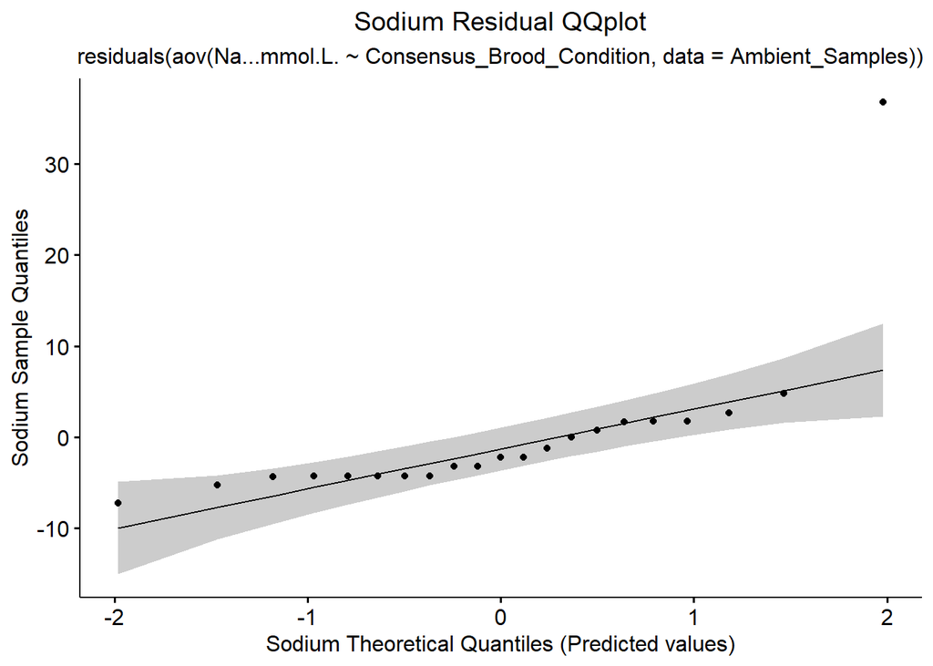

```r
# QQplot:
sodium_ambient_res_qqplot <- ggqqplot(residuals(aov(Na...mmol.L. ~ Consensus_Brood_Condition, data = Ambient_Samples))) +
labs(title = "Sodium Residual QQplot",
     subtitle = "residuals(aov(Na...mmol.L. ~ Consensus_Brood_Condition, data = Ambient_Samples))",
                               x = "Sodium Theoretical Quantiles (Predicted values)",
                               y = "Sodium Sample Quantiles") +
  theme(plot.title = element_text(hjust = 0.5),
        plot.subtitle = element_text(hjust = 0.5))
print(sodium_ambient_res_qqplot)
```

```r
# Parametric Variance test (Bartlett's test): require at least 2 obs for each group
# bartlett.test(Na...mmol.L. ~ Consensus_Brood_Condition, data = Ambient_Samples)

# Nonparametric variance test (Levene's test):
leveneTest(Na...mmol.L. ~ Consensus_Brood_Condition, data = Ambient_Samples)
```

```
## Levene's Test for Homogeneity of Variance (center = median)
##       Df F value Pr(>F)
## group  3   0.194  0.899
##       17
```

```r
# Nonparametric stat test: Kruskall Wallis
kruskal.test(Na...mmol.L. ~ Consensus_Brood_Condition, data = Ambient_Samples)
```

```
##
##  Kruskal-Wallis rank sum test
##
## data:  Na...mmol.L. by Consensus_Brood_Condition
## Kruskal-Wallis chi-squared = 5.5569, df = 3, p-value = 0.1353
```

```r
# Nonparametric Post Hoc: Dunns
DunnTest(Na...mmol.L. ~ Consensus_Brood_Condition, data = Ambient_Samples)
```

```
##
##  Dunn's test of multiple comparisons using rank sums : holm
##
##                   mean.rank.diff   pval
## Normal-Excellent       3.0000000 1.0000
## Low-Excellent         -5.5000000 1.0000
## Atresia-Excellent      3.5769231 1.0000
## Low-Normal            -8.5000000 0.3481
## Atresia-Normal         0.5769231 1.0000
## Atresia-Low            9.0769231 0.1252
## ---
## Signif. codes:  0 '***' 0.001 '**' 0.01 '*' 0.05 '.' 0.1 ' ' 1
```

Sodium Ambient Results

## Which brood condition significantly different (if any)?

Parametric assumptions: - Normality (Shapiro-Wilk test): **Not met** - Variance (Bartletts test): NA

- Nonparametric variance (Levene’s test): **Met**
- Nonparametric Post Hoc: Dunn’s Test
- Atresia-Low: mean.rank.diff = 9.0769231, pval = 0.1252

Differences: Between Fecundity Class

```r
# Na+
# Ambient ANOVA Test

# Testing for differences in ambient parturition success metrics
# One-way ANOVA (parametric) or Kruskal-Wallis test (nonparametric)

sodium_aov_ambient_fec <- aov(Na...mmol.L. ~ Fecundity_Class, data = Ambient_Samples)
summary(sodium_aov_ambient_fec)
```

```
##                 Df Sum Sq Mean Sq F value Pr(>F)
## Fecundity_Class  2  156.8   78.38   0.865  0.438
## Residuals       18 1631.8   90.66
```

```r
# If significant, Post Hoc Test:
# - Tukey's HSD (parametric, normality & equal variance across groups)
# - Dunn's test (non-parametric, after Kruskal-Wallis test)

TukeyHSD(sodium_aov_ambient_fec)
```

```
##   Tukey multiple comparisons of means
##     95% family-wise confidence level
##
## Fit: aov(formula = Na...mmol.L. ~ Fecundity_Class, data = Ambient_Samples)
##
## $Fecundity_Class
##                                   diff       lwr      upr     p adj
## Low (~1,000s)-High (>50,000) -2.000000 -19.18271 15.18271 0.9526465
## Atresia-High (>50,000)        4.480769  -9.41330 18.37484 0.6939179
## Atresia-Low (~1,000s)         6.480769  -7.41330 20.37484 0.4737484
```

```r
# Parametric tests

# Normality
shapiro.test(Ambient_Samples$Na...mmol.L.)
```

```
##
##  Shapiro-Wilk normality test
##
## data:  Ambient_Samples$Na...mmol.L.
## W = 0.52676, p-value = 3.625e-07
```

```r
shapiro.test(residuals(aov(Na...mmol.L. ~ Fecundity_Class, data = Ambient_Samples)))
```

```
##
##  Shapiro-Wilk normality test
##
## data:  residuals(aov(Na...mmol.L. ~ Fecundity_Class, data = Ambient_Samples))
## W = 0.56321, p-value = 8.235e-07
```

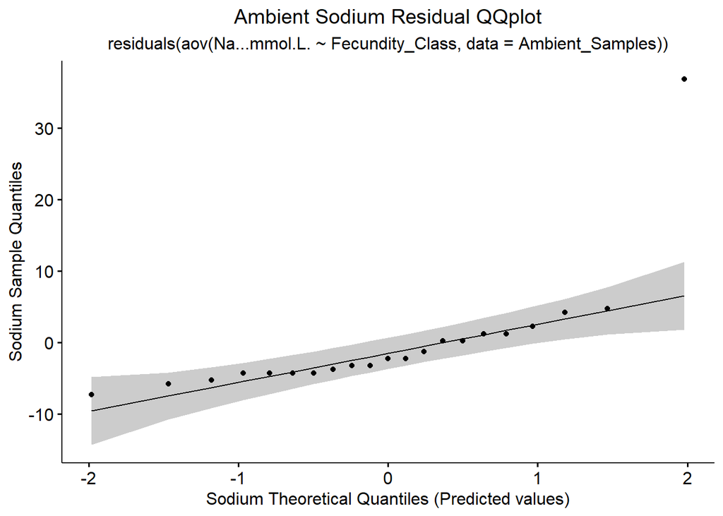

```r
# QQplot:
sodium_ambient_fec_res_qqplot <- ggqqplot(residuals(aov(Na...mmol.L. ~ Fecundity_Class, data = Ambient_Samples))) +
labs(title = "Ambient Sodium Residual QQplot",
     subtitle = "residuals(aov(Na...mmol.L. ~ Fecundity_Class, data = Ambient_Samples))",
                               x = "Sodium Theoretical Quantiles (Predicted values)",
                               y = "Sodium Sample Quantiles") +
  theme(plot.title = element_text(hjust = 0.5),
        plot.subtitle = element_text(hjust = 0.5))
print(sodium_ambient_fec_res_qqplot)
```

```r
# Parametric Variance test (Bartlett's test): require at least 2 obs for each group
bartlett.test(Na...mmol.L. ~ Fecundity_Class, data = Ambient_Samples)
```

```
##
##  Bartlett test of homogeneity of variances
##
## data:  Na...mmol.L. by Fecundity_Class
## Bartlett's K-squared = 7.4634, df = 2, p-value = 0.02395
```

```r
# Nonparametric variance test (Levene's test):
leveneTest(Na...mmol.L. ~ Fecundity_Class, data = Ambient_Samples)
```

```
## Levene's Test for Homogeneity of Variance (center = median)
##       Df F value Pr(>F)
## group  2  0.2098 0.8127
##       18
```

```r
# Nonparametric stat test: Kruskall Wallis
kruskal.test(Na...mmol.L. ~ Fecundity_Class, data = Ambient_Samples)
```

```
##
##  Kruskal-Wallis rank sum test
##
## data:  Na...mmol.L. by Fecundity_Class
## Kruskal-Wallis chi-squared = 2.8608, df = 2, p-value = 0.2392
```

```r
# Nonparametric Post Hoc: Dunn's test
DunnettTest(Na...mmol.L. ~ Fecundity_Class, data = Ambient_Samples)
```

```
##
##   Dunnett's test for comparing several treatments with a control :
##     95% family-wise confidence level
##
## $`High (>50,000)`
##                                   diff     lwr.ci   upr.ci   pval
## Low (~1,000s)-High (>50,000) -2.000000 -18.008265 14.00826 0.9321
## Atresia-High (>50,000)        4.480769  -8.463634 17.42517 0.6108
##
## ---
## Signif. codes:  0 '***' 0.001 '**' 0.01 '*' 0.05 '.' 0.1 ' ' 1
```

Sodium Ambient Results

## Which fecundity class significantly different (if any)?

Parametric assumptions: - Normality (Shapiro-Wilk test): **Not met** - Variance (Bartlett’s test): **Not Met**

Nonparametric variance test (Levene’s test): **Met**

Correlations: Parameter to Numerical Fecundity (without Atresia IDs)

```r
# Na+
# Linear Model
sodium_amb_fec_no_atresia_lm <- lm(Na...mmol.L. ~ Weight_Adjusted_Fecundity_Fecundity.Mean_Weight, data = Fecundity_No_Atresia_Samples)
summary(sodium_amb_fec_no_atresia_lm)
```

```
##
## Call:
## lm(formula = Na...mmol.L. ~ Weight_Adjusted_Fecundity_Fecundity.Mean_Weight,
##     data = Fecundity_No_Atresia_Samples)
##
## Residuals:
##     Min      1Q  Median      3Q     Max
## -7.1021 -0.3010  0.6449  1.9545  3.3374
##
## Coefficients:
##                                                  Estimate Std. Error t value
## (Intercept)                                     175.27869    2.08086  84.234
## Weight_Adjusted_Fecundity_Fecundity.Mean_Weight   0.00558    0.01091   0.511
##                                                 Pr(>|t|)
## (Intercept)                                      4.4e-13 ***
## Weight_Adjusted_Fecundity_Fecundity.Mean_Weight    0.623
## ---
## Signif. codes:  0 '***' 0.001 '**' 0.01 '*' 0.05 '.' 0.1 ' ' 1
##
## Residual standard error: 3.293 on 8 degrees of freedom
##   (18 observations deleted due to missingness)
## Multiple R-squared:  0.03166,    Adjusted R-squared:  -0.08939
## F-statistic: 0.2615 on 1 and 8 DF,  p-value: 0.6229
```

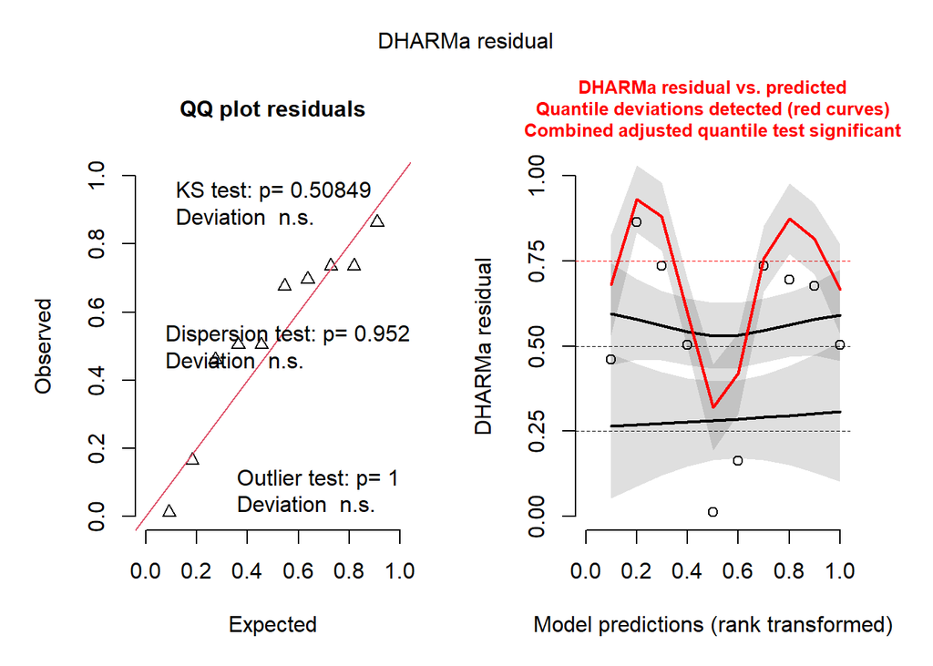

```r
sodium_ambient_sim <- simulateResiduals(fittedModel = sodium_amb_fec_no_atresia_lm)
plot(sodium_ambient_sim)
```

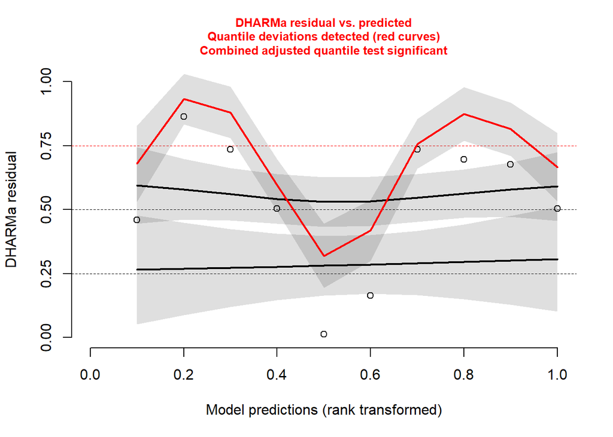

```r
plotResiduals(sodium_amb_fec_no_atresia_lm)
```

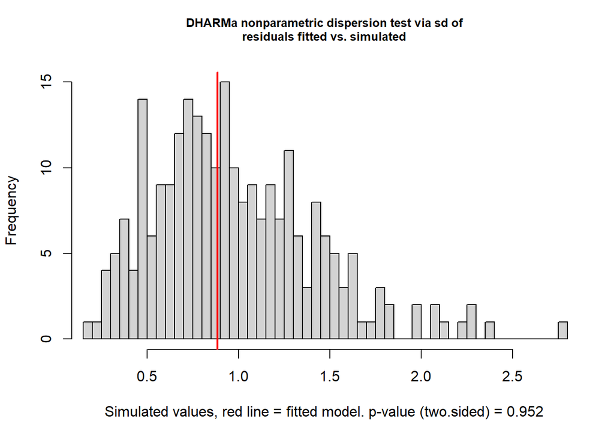

```
##
##  DHARMa nonparametric dispersion test via sd of residuals fitted vs.
##  simulated
##
## data:  simulationOutput
## dispersion = 0.90609, p-value = 0.952
## alternative hypothesis: two.sided
```

```r
testDispersion(sodium_amb_fec_no_atresia_lm)
```

```r
# Normailty test
shapiro.test(residuals(sodium_amb_fec_no_atresia_lm))
```

```
##
##  Shapiro-Wilk normality test
##
## data:  residuals(sodium_amb_fec_no_atresia_lm)
## W = 0.86592, p-value = 0.08956
```

```r
# Transform data: square root
sodium_ambient_sqrt <- Amb_Fec_No_Atresia_Samples %>%
  mutate(Na...mmol.L. = sqrt(Na...mmol.L.))

# Rerun lm model with square root transformed data
sodium_amb_fec_no_atresia_lm_sqrt <- lm(Na...mmol.L. ~ Weight_Adjusted_Fecundity_Fecundity.Mean_Weight, data = sodium_ambient_sqrt)
summary(sodium_amb_fec_no_atresia_lm_sqrt)
```

```
##
## Call:
## lm(formula = Na...mmol.L. ~ Weight_Adjusted_Fecundity_Fecundity.Mean_Weight,
##     data = sodium_ambient_sqrt)
##
## Residuals:
##      Min       1Q   Median       3Q      Max
## -0.25662 -0.03796  0.02115  0.09537  0.12926
##
## Coefficients:
##                                                  Estimate Std. Error t value
## (Intercept)                                     1.324e+01  8.923e-02  148.42
## Weight_Adjusted_Fecundity_Fecundity.Mean_Weight 8.630e-05  5.083e-04    0.17
##                                                 Pr(>|t|)
## (Intercept)                                     6.31e-12 ***
## Weight_Adjusted_Fecundity_Fecundity.Mean_Weight    0.871
## ---
## Signif. codes:  0 '***' 0.001 '**' 0.01 '*' 0.05 '.' 0.1 ' ' 1
##
## Residual standard error: 0.1393 on 6 degrees of freedom
## Multiple R-squared:  0.004782,   Adjusted R-squared:  -0.1611
## F-statistic: 0.02883 on 1 and 6 DF,  p-value: 0.8708
```

```
##
##  DHARMa: qgam was unable to calculate quantile regression for quantile 0.25. Possibly to few (unique) data points / predictions. The quantile will be ommited in plots and significance calculations.
```

```
##
##  DHARMa: qgam was unable to calculate quantile regression for quantile 0.5. Possibly to few (unique) data points / predictions. The quantile will be ommited in plots and significance calculations.
```

```
##
##  DHARMa: qgam was unable to calculate quantile regression for quantile 0.75. Possibly to few (unique) data points / predictions. The quantile will be ommited in plots and significance calculations.
```

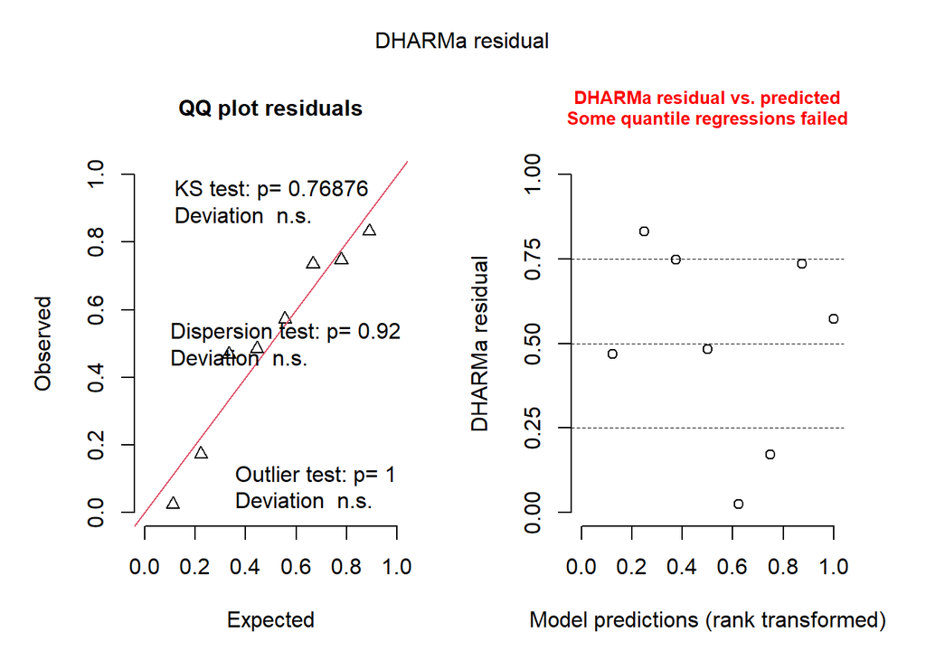

```r
sodium_amb_fec_sqrt_sim <- simulateResiduals(fittedModel = sodium_amb_fec_no_atresia_lm_sqrt)
plot(sodium_amb_fec_sqrt_sim)
```

```
##
##  DHARMa: qgam was unable to calculate quantile regression for quantile 0.25. Possibly to few (unique) data points / predictions. The quantile will be ommited in plots and significance calculations.
```

```
##
##  DHARMa: qgam was unable to calculate quantile regression for quantile 0.5. Possibly to few (unique) data points / predictions. The quantile will be ommited in plots and significance calculations.
```

```
##
##  DHARMa: qgam was unable to calculate quantile regression for quantile 0.75. Possibly to few (unique) data points / predictions. The quantile will be ommited in plots and significance calculations.
```

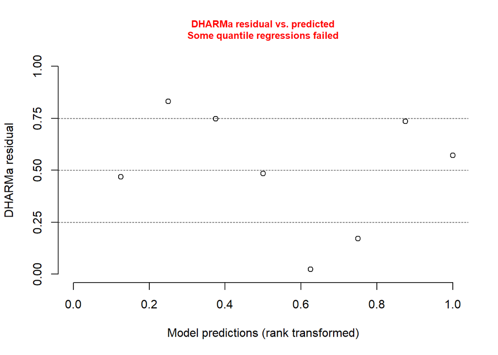

```r
plotResiduals(sodium_amb_fec_no_atresia_lm_sqrt)
```

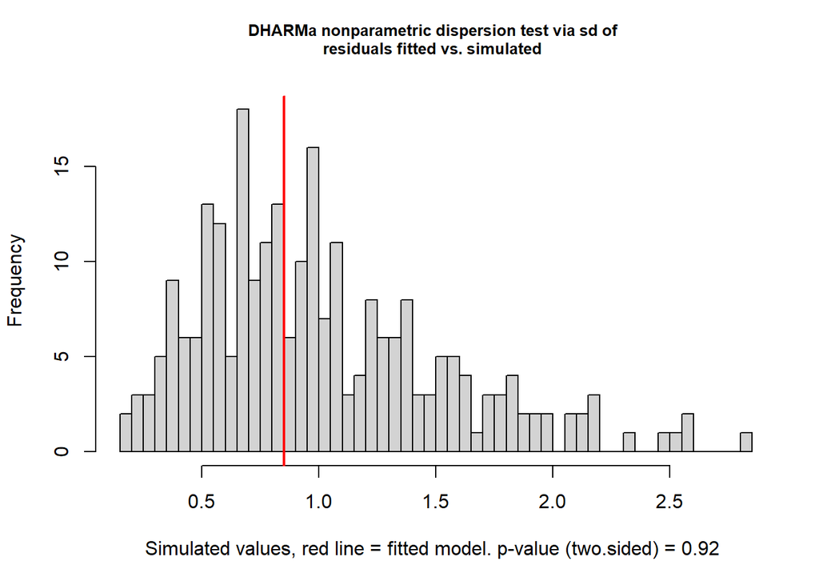

```
##
##  DHARMa nonparametric dispersion test via sd of residuals fitted vs.
##  simulated
##
## data:  simulationOutput
## dispersion = 0.84221, p-value = 0.92
## alternative hypothesis: two.sided
```

```r
testDispersion(sodium_amb_fec_no_atresia_lm_sqrt)
```

```r
# Residuals of model for shapiro test
sodium_amb_fec_no_atresia_lm_res <- residuals(sodium_amb_fec_no_atresia_lm_sqrt)

# Normality test
shapiro.test(sodium_amb_fec_no_atresia_lm_res)
```

```
##
##  Shapiro-Wilk normality test
##
## data:  sodium_amb_fec_no_atresia_lm_res
## W = 0.89593, p-value = 0.2654
```

```r
# Parametric variance test: bartlett's test
# Require at least 2 obs for each group
#bartlett.test(Na...mmol.L. ~ Weight_Adjusted_Fecundity_Fecundity.Mean_Weight, data = sodium_ambient_sqrt)

# Nonparametric variance test (Levene's test)
# NA for quantitative explanatory variables
# leveneTest(Na...mmol.L. ~ Weight_Adjusted_Fecundity_Fecundity.Mean_Weight, data = sodium_ambient_sqrt)
```

Sodium Ambient No Atresia Results

## Does a significant correlation exist between weight adj fecundity and parameter?

DHARMA Warning: Data dispersion error

Parametric assumptions: - Normality (Shapiro-Wilk test): **Not Met** - Variance (Bartlett’s test): NA

Nonparametric variance test (Levene’s test): NA

Residuals Plot (if significant)

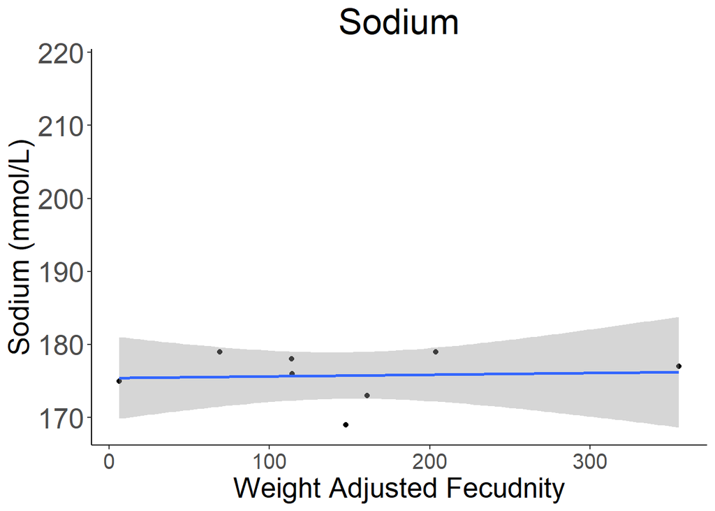

```r
# Na+
# Ambient samples

# ggplot with geom_smooth(aes(x=,y=)), method = "lm")

sodium_ambient_lm_scatterplot <- ggplot(data = Ambient_Samples, aes(x = Weight_Adjusted_Fecundity_Fecundity.Mean_Weight, y = Na...mmol.L.)) +
  geom_point() +
  geom_smooth(aes(group = 1), method = "lm") +
  labs(title = "Sodium", x = "Weight Adjusted Fecudnity", y = "Sodium (mmol/L)", color = "Category") +
  scale_y_continuous() +
  theme_classic() +
  theme(panel.background = element_rect(fill = "white"),
        plot.background = element_rect(fill = "white"),
        legend.background = element_rect(fill = "white", color = "black"),
        plot.title = element_text(size = 25, hjust = 0.5),
        axis.text.x = element_text(size = 15),
        axis.text.y = element_text(size = 20),
        axis.title.x = element_text(size = 20),
        axis.title.y = element_text(size = 20))

print(sodium_ambient_lm_scatterplot)
```

```r
ggsave(filename = "data-images/sodium_ambient_lm_scatterplot.pdf", plot = sodium_ambient_lm_scatterplot, device = "pdf")
ggsave(filename = "data-images/sodium_ambient_lm_scatterplot.png", plot = sodium_ambient_lm_scatterplot, device = "png")
```

# Cl- : Chloride

Chloride Summary Stats

```r
# Cl-
# Summary stats

# Ambient data
Ambient_Samples %>%
  group_by(Ambient.Or.OAH, Consensus_Brood_Condition) %>%
  summarize(count = n(),
            median = round(median(Cl...mmol.L.), 3),
            mean = round(mean(Cl...mmol.L.), 3),
            sd = round(sd(Cl...mmol.L.), 3),
            cv = round(sd(Cl...mmol.L.)/mean(Cl...mmol.L.), 3)) %>%
  ungroup()
```

```
## # A tibble: 4 × 7
##   Ambient.Or.OAH Consensus_Brood_Condition count median  mean     sd     cv
##   <ord>          <ord>                     <int>  <dbl> <dbl>  <dbl>  <dbl>
## 1 Ambient        Excellent                     1    158  158  NA     NA
## 2 Ambient        Normal                        4    160  159.  3.86   0.024
## 3 Ambient        Low                           3    156  156.  0.577  0.004
## 4 Ambient        Atresia                      13    158  158.  4.61   0.029
```

```r
Ambient_Samples %>%
  group_by(Ambient.Or.OAH, Fecundity_Class) %>%
  summarize(count = n(),
            median = round(median(Cl...mmol.L.), 3),
            mean = round(mean(Cl...mmol.L.), 3),
            sd = round(sd(Cl...mmol.L.), 3),
            cv = round(sd(Cl...mmol.L.)/mean(Cl...mmol.L.), 3)) %>%
  ungroup()
```

```
## # A tibble: 3 × 7
##   Ambient.Or.OAH Fecundity_Class count median  mean    sd    cv
##   <ord>          <ord>           <int>  <dbl> <dbl> <dbl> <dbl>
## 1 Ambient        High (>50,000)      4   158.  158   2.94 0.019
## 2 Ambient        Low (~1,000s)       4   156   158.  3.70 0.023
## 3 Ambient        Atresia            13   158   158.  4.61 0.029
```

```r
Amb_Fec_No_Atresia_Samples %>%
  group_by(Ambient.Or.OAH, Fecundity_Class) %>%
  summarize(count = n(),
            median = round(median(Cl...mmol.L.), 3),
            mean = round(mean(Cl...mmol.L.), 3),
            sd = round(sd(Cl...mmol.L.), 3),
            cv = round(sd(Cl...mmol.L.)/mean(Cl...mmol.L.), 3)) %>%
  ungroup()
```

```
## # A tibble: 2 × 7
##   Ambient.Or.OAH Fecundity_Class count median  mean    sd    cv
##   <ord>          <ord>           <int>  <dbl> <dbl> <dbl> <dbl>
## 1 Ambient        High (>50,000)      4   158.  158   2.94 0.019
## 2 Ambient        Low (~1,000s)       4   156   158.  3.70 0.023
```

Chloride Boxplot

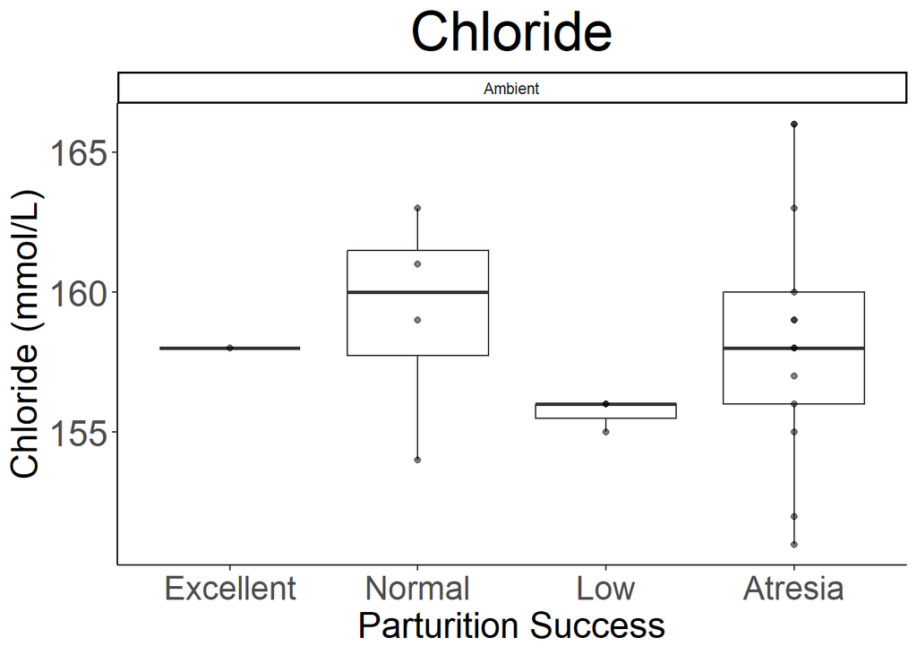

```r
# Cl- boxplot

# Ambient Samples
chloride_ambient_boxplot <- ggplot(data = Ambient_Samples) +
  geom_boxplot(aes(x = Consensus_Brood_Condition, y = Cl...mmol.L.)) +
  geom_point(aes(x = Consensus_Brood_Condition, y = Cl...mmol.L.), alpha = 0.5, colour = "black") +
  labs(title = "Chloride", x = "Parturition Success", y = "Chloride (mmol/L)") +
  facet_wrap(~ Ambient.Or.OAH) +
  theme_classic() +
  theme(panel.background = element_rect(fill = "white"),
        plot.background = element_rect(fill = "white"),
        legend.background = element_rect(fill = "white", color = "black"),
        title = element_text(size = 12),
        plot.title = element_text(size = 30, hjust = 0.5),
        axis.text.x = element_text(size = 18),
        axis.text.y = element_text(size = 20),
        axis.title.x = element_text(size = 20),
        axis.title.y = element_text(size = 20))

print(chloride_ambient_boxplot)
```

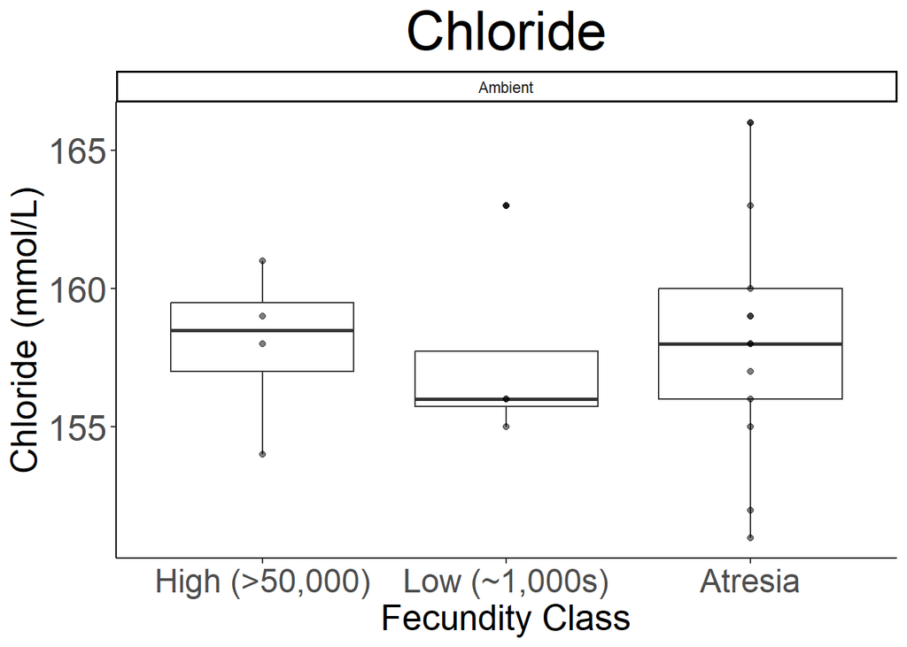

```r
ggsave(filename = "data-images/chloride_ambient_boxplot.pdf", plot = chloride_ambient_boxplot, device = "pdf")
ggsave(filename = "data-images/chloride_ambient_boxplot.png", plot = chloride_ambient_boxplot, device = "png")
chloride_ambient_fecundity_boxplot <- ggplot(data = Ambient_Samples) +
  geom_boxplot(aes(x = Fecundity_Class, y = Cl...mmol.L.)) +
  geom_point(aes(x = Fecundity_Class, y = Cl...mmol.L.), alpha = 0.5, colour = "black") +
  labs(title = "Chloride", x = "Fecundity Class", y = "Chloride (mmol/L)") +
  facet_wrap(~ Ambient.Or.OAH) +
  theme_classic() +
  theme(panel.background = element_rect(fill = "white"),
        plot.background = element_rect(fill = "white"),
        legend.background = element_rect(fill = "white", color = "black"),
        title = element_text(size = 12),
        plot.title = element_text(size = 30, hjust = 0.5),
        axis.text.x = element_text(size = 18),
        axis.text.y = element_text(size = 20),
        axis.title.x = element_text(size = 20),
        axis.title.y = element_text(size = 20))

print(chloride_ambient_fecundity_boxplot)
```

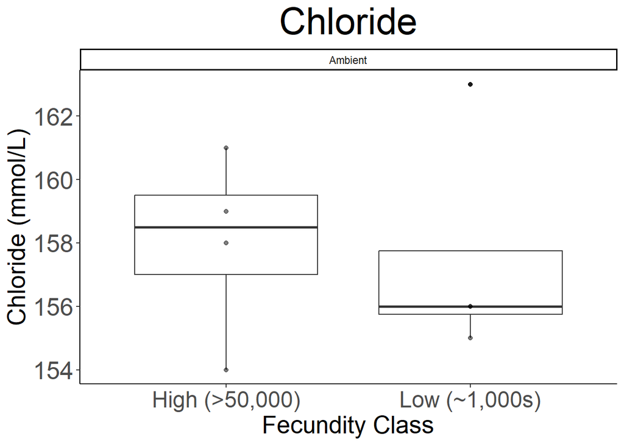

```r
ggsave(filename = "data-images/chloride_ambient_fecundity_boxplot.pdf", plot = chloride_ambient_fecundity_boxplot, device = "pdf")
ggsave(filename = "data-images/chloride_ambient_fecundity_boxplot.png", plot = chloride_ambient_fecundity_boxplot, device = "png")
chloride_amb_fec_no_atresia_boxplot <- ggplot(data = Amb_Fec_No_Atresia_Samples) +
  geom_boxplot(aes(x = Fecundity_Class, y = Cl...mmol.L.)) +
  geom_point(aes(x = Fecundity_Class, y = Cl...mmol.L.), alpha = 0.5, colour = "black") +
  labs(title = "Chloride", x = "Fecundity Class", y = "Chloride (mmol/L)") +
  facet_wrap(~ Ambient.Or.OAH) +
  theme_classic() +
  theme(panel.background = element_rect(fill = "white"),
        plot.background = element_rect(fill = "white"),
        legend.background = element_rect(fill = "white", color = "black"),
        title = element_text(size = 12),
        plot.title = element_text(size = 30, hjust = 0.5),
        axis.text.x = element_text(size = 18),
        axis.text.y = element_text(size = 20),
        axis.title.x = element_text(size = 20),
        axis.title.y = element_text(size = 20))

print(chloride_amb_fec_no_atresia_boxplot)
```

[figure not shown]

```r
ggsave(filename = "data-images/chloride_amb_fec_no_atresia_boxplot.pdf", plot = chloride_amb_fec_no_atresia_boxplot, device = "pdf")
ggsave(filename = "data-images/chloride_amb_fec_no_atresia_boxplot.png", plot = chloride_amb_fec_no_atresia_boxplot, device = "png")
chloride_amb_fec_no_atresia_scatterplot <- Amb_Fec_No_Atresia_Samples %>%
  ggplot() +
  geom_point(aes(x = Weight_Adjusted_Fecundity_Fecundity.Mean_Weight, y = Na...mmol.L.), colour = "black") +
  labs(title = "Chloride", x = "Weight Adjusted Fecundity", y = "Chloride (mmol/L)") +
  facet_wrap(~ Ambient.Or.OAH) +
  theme_classic() +
  theme(panel.background = element_rect(fill = "white"),
        plot.background = element_rect(fill = "white"),
        legend.background = element_rect(fill = "white", color = "black"),
        title = element_text(size = 12),
        plot.title = element_text(size = 30, hjust = 0.5),
        axis.text.x = element_text(size = 20),
        axis.text.y = element_text(size = 20),
        axis.title.x = element_text(size = 20),
        axis.title.y = element_text(size = 20))

print(chloride_amb_fec_no_atresia_scatterplot)
```

```r
ggsave(filename = "data-images/chloride_amb_fec_no_atresia_scatterplot.pdf", plot = chloride_amb_fec_no_atresia_scatterplot, device = "pdf")
ggsave(filename = "data-images/chloride_amb_fec_no_atresia_scatterplot.pdf", plot = chloride_amb_fec_no_atresia_scatterplot, device = "png")
```

Differences: Between Brood Conditon

```r
# Na+
# Ambient ANOVA Test

# Testing for differences in ambient parturition success metrics
# One-way ANOVA (parametric) or Kruskal-Wallis test (nonparametric)

sodium_aov_ambient_brood <- aov(Na...mmol.L. ~ Consensus_Brood_Condition, data = Ambient_Samples)
summary(sodium_aov_ambient_brood)
```

```
##                           Df Sum Sq Mean Sq F value Pr(>F)
## Consensus_Brood_Condition  3  176.8   58.95   0.622  0.611
## Residuals                 17 1611.7   94.81
```

```r
# If significant, Post Hoc Test:
# - Tukey's HSD (parametric, normality & equal variance across groups)
# - Dunn's test (non-parametric, after Kruskal-Wallis test)

TukeyHSD(sodium_aov_ambient_brood)
```

```
##   Tukey multiple comparisons of means
##     95% family-wise confidence level
##
## Fit: aov(formula = Na...mmol.L. ~ Consensus_Brood_Condition, data = Ambient_Samples)
##
## $Consensus_Brood_Condition
##                        diff        lwr      upr     p adj
## Normal-Excellent   0.250000 -30.694633 31.19463 0.9999955
## Low-Excellent     -3.666667 -35.626146 28.29281 0.9875929
## Atresia-Excellent  4.230769 -24.491760 32.95330 0.9745138
## Low-Normal        -3.916667 -25.055875 17.22254 0.9514394
## Atresia-Normal     3.980769 -11.844573 19.80611 0.8897586
## Atresia-Low        7.897436  -9.830494 25.62537 0.5954090
```

```r
# Parametric tests

# Normality
shapiro.test(Ambient_Samples$Na...mmol.L.)
```

```
##
##  Shapiro-Wilk normality test
##
## data:  Ambient_Samples$Na...mmol.L.
## W = 0.52676, p-value = 3.625e-07
```

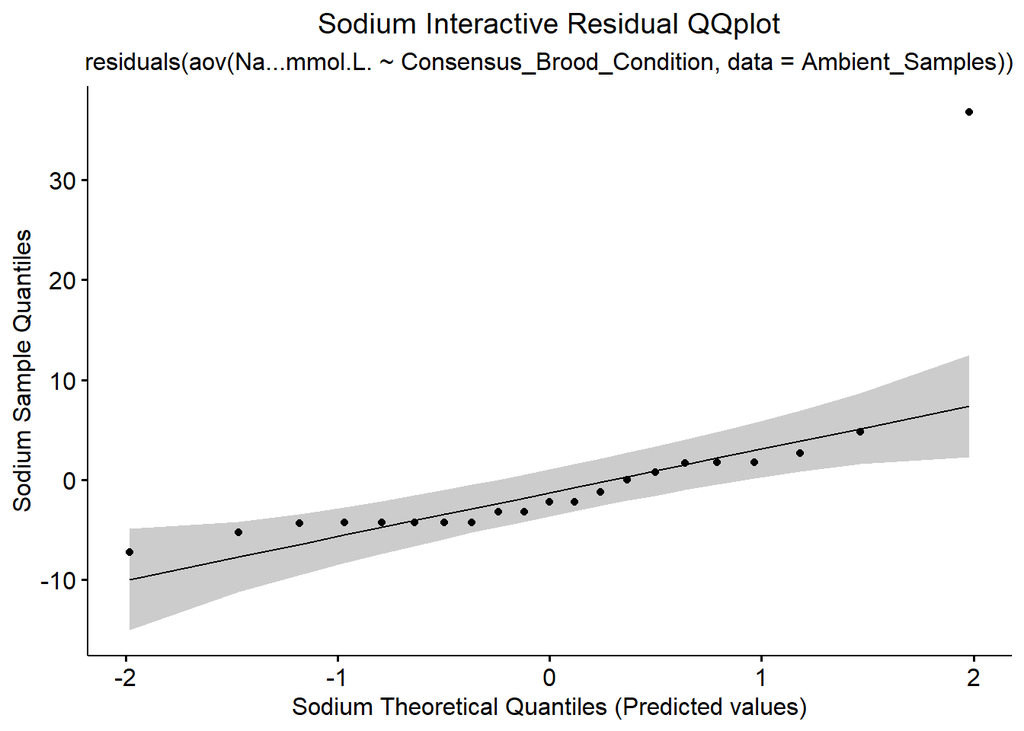

```r
# QQplot:
sodium_ambient_res_qqplot <- ggqqplot(residuals(aov(Na...mmol.L. ~ Consensus_Brood_Condition, data = Ambient_Samples))) +
labs(title = "Sodium Interactive Residual QQplot",
     subtitle = "residuals(aov(Na...mmol.L. ~ Consensus_Brood_Condition, data = Ambient_Samples))",
                               x = "Sodium Theoretical Quantiles (Predicted values)",
                               y = "Sodium Sample Quantiles") +
  theme(plot.title = element_text(hjust = 0.5),
        plot.subtitle = element_text(hjust = 0.5))
print(sodium_ambient_res_qqplot)
```

```r
# Parametric Variance test (Bartlett's test): require at least 2 obs for each group
# bartlett.test(Na...mmol.L. ~ Consensus_Brood_Condition, data = Ambient_Samples)

# Nonparametric variance test (Levene's test):
leveneTest(Na...mmol.L. ~ Consensus_Brood_Condition, data = Ambient_Samples)
```

```
## Levene's Test for Homogeneity of Variance (center = median)
##       Df F value Pr(>F)
## group  3   0.194  0.899
##       17
```

```r
# Nonparametric stat test: Dunns
DunnTest(Na...mmol.L. ~ Consensus_Brood_Condition, data = Ambient_Samples)
```

```
##
##  Dunn's test of multiple comparisons using rank sums : holm
##
##                   mean.rank.diff   pval
## Normal-Excellent       3.0000000 1.0000
## Low-Excellent         -5.5000000 1.0000
## Atresia-Excellent      3.5769231 1.0000
## Low-Normal            -8.5000000 0.3481
## Atresia-Normal         0.5769231 1.0000
## Atresia-Low            9.0769231 0.1252
## ---
## Signif. codes:  0 '***' 0.001 '**' 0.01 '*' 0.05 '.' 0.1 ' ' 1
```

Sodium Ambient Results

## Which brood condition significantly different (if any)?

Parametric assumptions: - Normality (Shapiro-Wilk test): **Not met** - Variance (Bartletts test): NA

- Nonparametric variance (Levene’s test): **Met**
- Nonparametric Post Hoc: Dunn’s Test
- Atresia-Low: mean.rank.diff = 9.0769231, pval = 0.1252

Differences: Between Fecundity Class

```r
# Na+
# Ambient ANOVA Test

# Testing for differences in ambient parturition success metrics
# One-way ANOVA (parametric) or Kruskal-Wallis test (nonparametric)

sodium_aov_ambient_fec <- aov(Na...mmol.L. ~ Fecundity_Class, data = Ambient_Samples)
summary(sodium_aov_ambient_fec)
```

```
##                 Df Sum Sq Mean Sq F value Pr(>F)
## Fecundity_Class  2  156.8   78.38   0.865  0.438
## Residuals       18 1631.8   90.66
```

```r
# If significant, Post Hoc Test:
# - Tukey's HSD (parametric, normality & equal variance across groups)
# - Dunn's test (non-parametric, after Kruskal-Wallis test)

TukeyHSD(sodium_aov_ambient_fec)
```

```
##   Tukey multiple comparisons of means
##     95% family-wise confidence level
##
## Fit: aov(formula = Na...mmol.L. ~ Fecundity_Class, data = Ambient_Samples)
##
## $Fecundity_Class
##                                   diff       lwr      upr     p adj
## Low (~1,000s)-High (>50,000) -2.000000 -19.18271 15.18271 0.9526465
## Atresia-High (>50,000)        4.480769  -9.41330 18.37484 0.6939179
## Atresia-Low (~1,000s)         6.480769  -7.41330 20.37484 0.4737484
```

```r
# Parametric tests

# Normality
shapiro.test(Ambient_Samples$Na...mmol.L.)
```

```
##
##  Shapiro-Wilk normality test
##
## data:  Ambient_Samples$Na...mmol.L.
## W = 0.52676, p-value = 3.625e-07
```

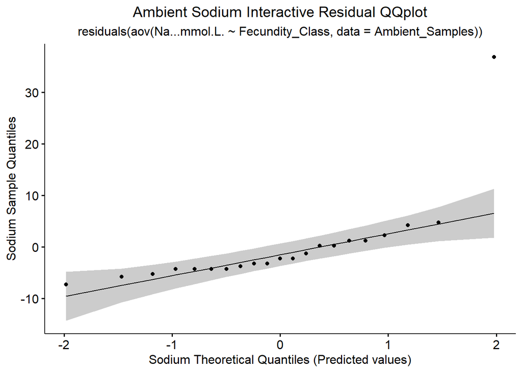

```r
# QQplot:
sodium_ambient_fec_res_qqplot <- ggqqplot(residuals(aov(Na...mmol.L. ~ Fecundity_Class, data = Ambient_Samples))) +
labs(title = "Ambient Sodium Interactive Residual QQplot",
     subtitle = "residuals(aov(Na...mmol.L. ~ Fecundity_Class, data = Ambient_Samples))",
                               x = "Sodium Theoretical Quantiles (Predicted values)",
                               y = "Sodium Sample Quantiles") +
  theme(plot.title = element_text(hjust = 0.5),
        plot.subtitle = element_text(hjust = 0.5))
print(sodium_ambient_fec_res_qqplot)
```

```r
# Parametric Variance test (Bartlett's test): require at least 2 obs for each group
#bartlett.test(Na...mmol.L. ~ Fecundity_Class, data = Ambient_Samples)

# Nonparametric variance test (Levene's test):
leveneTest(Na...mmol.L. ~ Fecundity_Class, data = Ambient_Samples)
```

```
## Levene's Test for Homogeneity of Variance (center = median)
##       Df F value Pr(>F)
## group  2  0.2098 0.8127
##       18
```

```r
# Nonparametric stat test: Dunns
DunnettTest(Na...mmol.L. ~ Fecundity_Class, data = Ambient_Samples)
```

```
##
##   Dunnett's test for comparing several treatments with a control :
##     95% family-wise confidence level
##
## $`High (>50,000)`
##                                   diff     lwr.ci   upr.ci   pval
## Low (~1,000s)-High (>50,000) -2.000000 -18.008265 14.00826 0.9321
## Atresia-High (>50,000)        4.480769  -8.463634 17.42517 0.6108
##
## ---
## Signif. codes:  0 '***' 0.001 '**' 0.01 '*' 0.05 '.' 0.1 ' ' 1
```

Sodium Ambient Results

## Which fecundity class significantly different (if any)?

Parametric assumptions: - Normality (Shapiro-Wilk test): **Not met** - Variance (Bartlett’s test): NA

Nonparametric variance test (Levene’s test): **Met**

Correlations: Parameter to Numerical Fecundity (without Atresia IDs)

```r
# Na+
# Linear Model
sodium_amb_fec_no_atresia_lm <- lm(Na...mmol.L. ~ Weight_Adjusted_Fecundity_Fecundity.Mean_Weight, data = Fecundity_No_Atresia_Samples)
summary(sodium_amb_fec_no_atresia_lm)
```

```
##
## Call:
## lm(formula = Na...mmol.L. ~ Weight_Adjusted_Fecundity_Fecundity.Mean_Weight,
##     data = Fecundity_No_Atresia_Samples)
##
## Residuals:
##     Min      1Q  Median      3Q     Max
## -7.1021 -0.3010  0.6449  1.9545  3.3374
##
## Coefficients:
##                                                  Estimate Std. Error t value
## (Intercept)                                     175.27869    2.08086  84.234
## Weight_Adjusted_Fecundity_Fecundity.Mean_Weight   0.00558    0.01091   0.511
##                                                 Pr(>|t|)
## (Intercept)                                      4.4e-13 ***
## Weight_Adjusted_Fecundity_Fecundity.Mean_Weight    0.623
## ---
## Signif. codes:  0 '***' 0.001 '**' 0.01 '*' 0.05 '.' 0.1 ' ' 1
##
## Residual standard error: 3.293 on 8 degrees of freedom
##   (18 observations deleted due to missingness)
## Multiple R-squared:  0.03166,    Adjusted R-squared:  -0.08939
## F-statistic: 0.2615 on 1 and 8 DF,  p-value: 0.6229
```

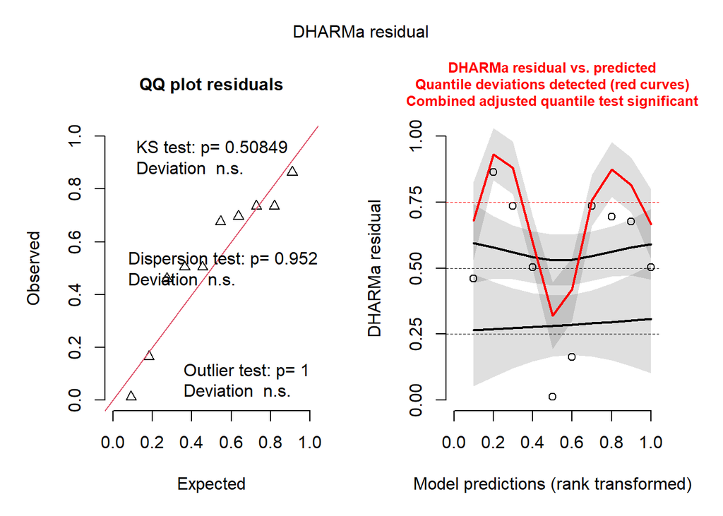

```r
sodium_ambient_sim <- simulateResiduals(fittedModel = sodium_amb_fec_no_atresia_lm)
plot(sodium_ambient_sim)
```

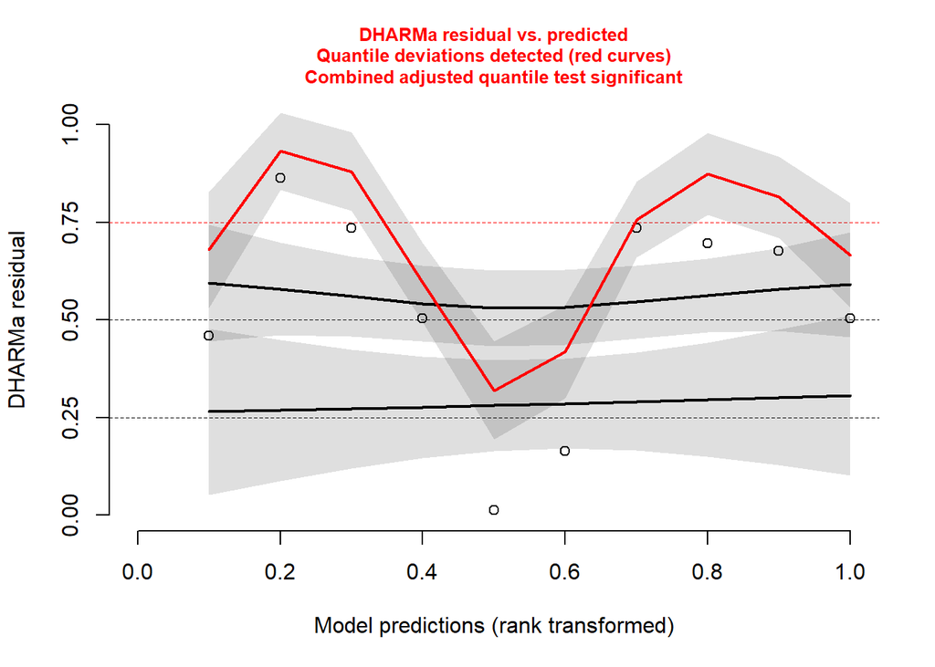

```r
plotResiduals(sodium_amb_fec_no_atresia_lm)
```

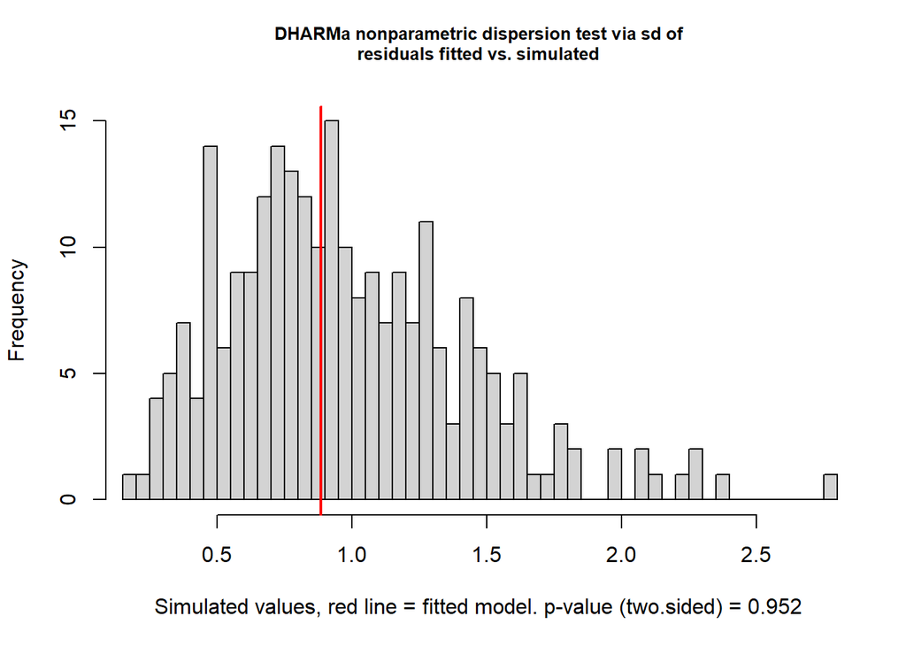

```
##
##  DHARMa nonparametric dispersion test via sd of residuals fitted vs.
##  simulated
##
## data:  simulationOutput
## dispersion = 0.90609, p-value = 0.952
## alternative hypothesis: two.sided
```

```r
testDispersion(sodium_amb_fec_no_atresia_lm)
```

```r
# Transform data: square root
sodium_ambient_sqrt <- Amb_Fec_No_Atresia_Samples %>%
  mutate(Na...mmol.L. = sqrt(Na...mmol.L.))

# Rerun lm model with square root transformed data
sodium_amb_fec_no_atresia_lm_sqrt <- lm(Na...mmol.L. ~ Weight_Adjusted_Fecundity_Fecundity.Mean_Weight, data = sodium_ambient_sqrt)
summary(sodium_amb_fec_no_atresia_lm_sqrt)
```

```
##
## Call:
## lm(formula = Na...mmol.L. ~ Weight_Adjusted_Fecundity_Fecundity.Mean_Weight,
##     data = sodium_ambient_sqrt)
##
## Residuals:
##      Min       1Q   Median       3Q      Max
## -0.25662 -0.03796  0.02115  0.09537  0.12926
##
## Coefficients:
##                                                  Estimate Std. Error t value
## (Intercept)                                     1.324e+01  8.923e-02  148.42
## Weight_Adjusted_Fecundity_Fecundity.Mean_Weight 8.630e-05  5.083e-04    0.17
##                                                 Pr(>|t|)
## (Intercept)                                     6.31e-12 ***
## Weight_Adjusted_Fecundity_Fecundity.Mean_Weight    0.871
## ---
## Signif. codes:  0 '***' 0.001 '**' 0.01 '*' 0.05 '.' 0.1 ' ' 1
##
## Residual standard error: 0.1393 on 6 degrees of freedom
## Multiple R-squared:  0.004782,   Adjusted R-squared:  -0.1611
## F-statistic: 0.02883 on 1 and 6 DF,  p-value: 0.8708
```

```
##
##  DHARMa: qgam was unable to calculate quantile regression for quantile 0.25. Possibly to few (unique) data points / predictions. The quantile will be ommited in plots and significance calculations.
```

```
##
##  DHARMa: qgam was unable to calculate quantile regression for quantile 0.5. Possibly to few (unique) data points / predictions. The quantile will be ommited in plots and significance calculations.
```

```
##
##  DHARMa: qgam was unable to calculate quantile regression for quantile 0.75. Possibly to few (unique) data points / predictions. The quantile will be ommited in plots and significance calculations.
```

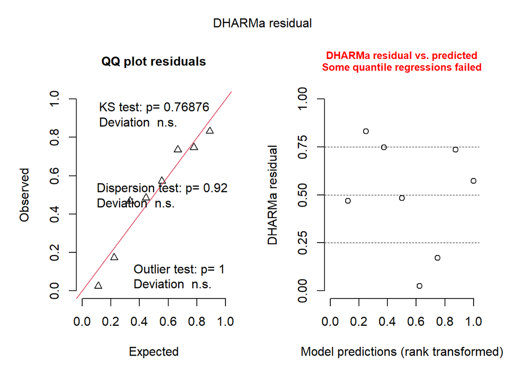

```r
sodium_amb_fec_sqrt_sim <- simulateResiduals(fittedModel = sodium_amb_fec_no_atresia_lm_sqrt)
plot(sodium_amb_fec_sqrt_sim)
```

```
##
##  DHARMa: qgam was unable to calculate quantile regression for quantile 0.25. Possibly to few (unique) data points / predictions. The quantile will be ommited in plots and significance calculations.
```

```
##
##  DHARMa: qgam was unable to calculate quantile regression for quantile 0.5. Possibly to few (unique) data points / predictions. The quantile will be ommited in plots and significance calculations.
```

```
##
##  DHARMa: qgam was unable to calculate quantile regression for quantile 0.75. Possibly to few (unique) data points / predictions. The quantile will be ommited in plots and significance calculations.
```

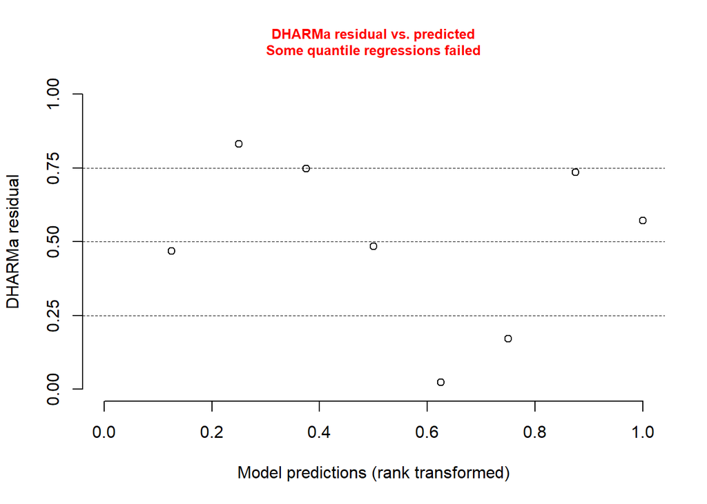

```r
plotResiduals(sodium_amb_fec_no_atresia_lm_sqrt)
```

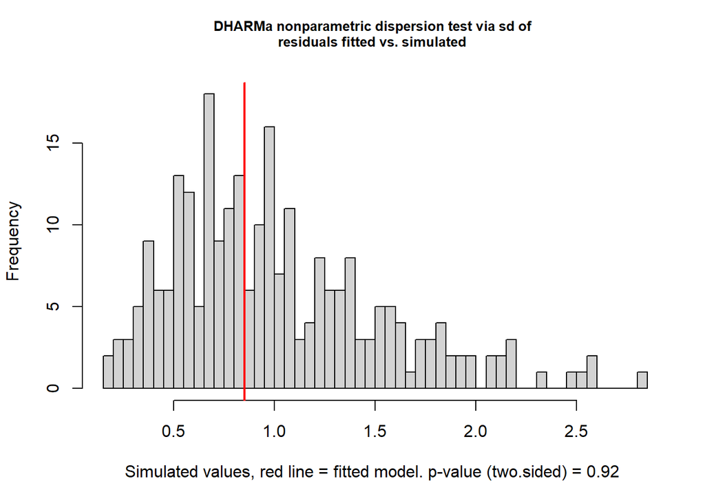

```
##
##  DHARMa nonparametric dispersion test via sd of residuals fitted vs.
##  simulated
##
## data:  simulationOutput
## dispersion = 0.84221, p-value = 0.92
## alternative hypothesis: two.sided
```

```r
testDispersion(sodium_amb_fec_no_atresia_lm_sqrt)
```

```r
# Residuals of model for shapiro test
sodium_amb_fec_no_atresia_lm_res <- residuals(sodium_amb_fec_no_atresia_lm_sqrt)

# Normality test
shapiro.test(sodium_amb_fec_no_atresia_lm_res)
```

```
##
##  Shapiro-Wilk normality test
##
## data:  sodium_amb_fec_no_atresia_lm_res
## W = 0.89593, p-value = 0.2654
```

```r
# Parametric variance test: bartlett's test
# Require at least 2 obs for each group
#bartlett.test(Na...mmol.L. ~ Weight_Adjusted_Fecundity_Fecundity.Mean_Weight, data = sodium_ambient_sqrt)

# Nonparametric variance test (Levene's test)
# NA for quantitative explanatory variables
# leveneTest(Na...mmol.L. ~ Weight_Adjusted_Fecundity_Fecundity.Mean_Weight, data = sodium_ambient_sqrt)
```

Sodium Ambient No Atresia Results

## Does a significant correlation exist between weight adj fecundity and parameter?

Parametric assumptions: - Normality (Shapiro-Wilk test): **Met** - Variance (Bartlett’s test): NA

Nonparametric variance test (Levene’s test): NA

Residuals Plot (if significant)

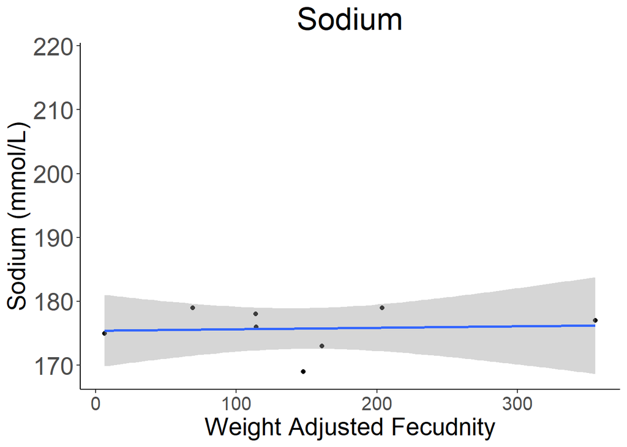

```r
# Na+
# Ambient samples

# ggplot with geom_smooth(aes(x=,y=)), method = "lm")

sodium_ambient_lm_scatterplot <- ggplot(data = Ambient_Samples, aes(x = Weight_Adjusted_Fecundity_Fecundity.Mean_Weight, y = Na...mmol.L.)) +
  geom_point() +
  geom_smooth(aes(group = 1), method = "lm") +
  labs(title = "Sodium", x = "Weight Adjusted Fecudnity", y = "Sodium (mmol/L)", color = "Category") +
  scale_y_continuous() +
  theme_classic() +
  theme(panel.background = element_rect(fill = "white"),
        plot.background = element_rect(fill = "white"),
        legend.background = element_rect(fill = "white", color = "black"),
        plot.title = element_text(size = 25, hjust = 0.5),
        axis.text.x = element_text(size = 15),
        axis.text.y = element_text(size = 20),
        axis.title.x = element_text(size = 20),
        axis.title.y = element_text(size = 20))

print(sodium_ambient_lm_scatterplot)
```

```r
ggsave(filename = "data-images/sodium_ambient_lm_scatterplot.pdf", plot = sodium_ambient_lm_scatterplot, device = "pdf")
ggsave(filename = "data-images/sodium_ambient_lm_scatterplot.png", plot = sodium_ambient_lm_scatterplot, device = "png")
```

# Cl- Stat Tests

Differences: Between Brood Condition

```r
# Cl-
# Ambient ANOVA Test

# Testing for differences in ambient parturition success metrics
# One-way ANOVA (parametric) or Kruskal-Wallis test (nonparametric)

chloride_aov_ambient_brood <- aov(Cl...mmol.L. ~ Consensus_Brood_Condition, data = Ambient_Samples)
summary(chloride_aov_ambient_brood)
```

```
##                           Df Sum Sq Mean Sq F value Pr(>F)
## Consensus_Brood_Condition  3  24.59   8.197   0.463  0.711
## Residuals                 17 300.65  17.685
```

```r
# If significant, Post Hoc Test:
# - Tukey's HSD (parametric, normality & equal variance across groups)
# - Dunn's test (non-parametric, after Kruskal-Wallis test)

TukeyHSD(chloride_aov_ambient_brood)
```

```
##   Tukey multiple comparisons of means
##     95% family-wise confidence level
##
## Fit: aov(formula = Cl...mmol.L. ~ Consensus_Brood_Condition, data = Ambient_Samples)
##
## $Consensus_Brood_Condition
##                         diff        lwr       upr     p adj
## Normal-Excellent   1.2500000 -12.114992 14.614992 0.9931731
## Low-Excellent     -2.3333333 -16.136638 11.469971 0.9623849
## Atresia-Excellent  0.4615385 -11.943726 12.866803 0.9995589
## Low-Normal        -3.5833333 -12.713361  5.546694 0.6851430
## Atresia-Normal    -0.7884615  -7.623430  6.046506 0.9873943
## Atresia-Low        2.7948718  -4.861824 10.451567 0.7302966
```

```r
# Parametric tests

# Normality
shapiro.test(Ambient_Samples$Cl...mmol.L.)
```

```
##
##  Shapiro-Wilk normality test
##
## data:  Ambient_Samples$Cl...mmol.L.
## W = 0.96502, p-value = 0.6224
```

```r
shapiro.test(residuals(aov(Cl...mmol.L. ~ Consensus_Brood_Condition, data = Ambient_Samples)))
```

```
##
##  Shapiro-Wilk normality test
##
## data:  residuals(aov(Cl...mmol.L. ~ Consensus_Brood_Condition, data = Ambient_Samples))
## W = 0.9502, p-value = 0.3437
```

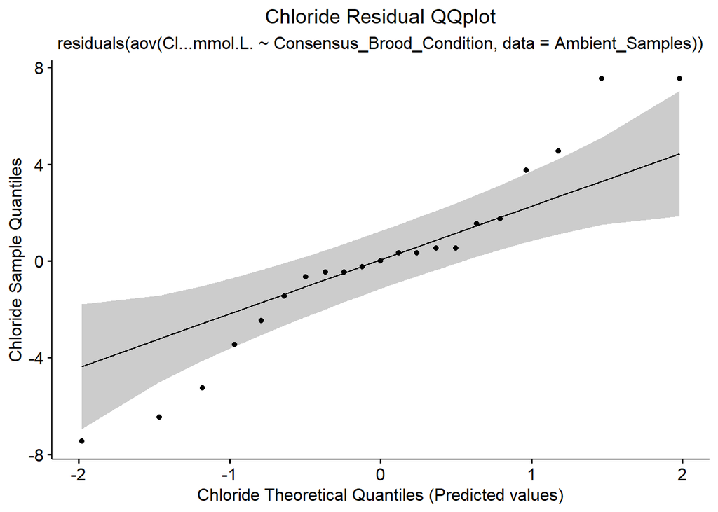

```r
# QQplot:
chloride_ambient_res_qqplot <- ggqqplot(residuals(aov(Cl...mmol.L. ~ Consensus_Brood_Condition, data = Ambient_Samples))) +
labs(title = "Chloride Residual QQplot",
     subtitle = "residuals(aov(Cl...mmol.L. ~ Consensus_Brood_Condition, data = Ambient_Samples))",
                               x = "Chloride Theoretical Quantiles (Predicted values)",
                               y = "Chloride Sample Quantiles") +
  theme(plot.title = element_text(hjust = 0.5),
        plot.subtitle = element_text(hjust = 0.5))
print(chloride_ambient_res_qqplot)
```

```r
# Parametric Variance test (Bartlett's test): require at least 2 obs for each group
# bartlett.test(Cl...mmol.L. ~ Consensus_Brood_Condition, data = Ambient_Samples)

# Nonparametric variance test (Levene's test):
leveneTest(Cl...mmol.L. ~ Consensus_Brood_Condition, data = Ambient_Samples)
```

```
## Levene's Test for Homogeneity of Variance (center = median)
##       Df F value Pr(>F)
## group  3  1.3517  0.291
##       17
```

```r
# Nonparametric stat test: Kruskall Wallis
kruskal.test(Cl...mmol.L. ~ Consensus_Brood_Condition, data = Ambient_Samples)
```

```
##
##  Kruskal-Wallis rank sum test
##
## data:  Cl...mmol.L. by Consensus_Brood_Condition
## Kruskal-Wallis chi-squared = 2.3847, df = 3, p-value = 0.4965
```

```r
# Nonparametric Post Hoc: Dunns
DunnTest(Cl...mmol.L. ~ Consensus_Brood_Condition, data = Ambient_Samples)
```

```
##
##  Dunn's test of multiple comparisons using rank sums : holm
##
##                   mean.rank.diff   pval
## Normal-Excellent       2.1250000 1.0000
## Low-Excellent         -4.8333333 1.0000
## Atresia-Excellent      0.4615385 1.0000
## Low-Normal            -6.9583333 0.8405
## Atresia-Normal        -1.6634615 1.0000
## Atresia-Low            5.2948718 0.9031
## ---
## Signif. codes:  0 '***' 0.001 '**' 0.01 '*' 0.05 '.' 0.1 ' ' 1
```

Chloride Ambient Results

## Which brood condition significantly different (if any)?

Parametric assumptions: - Normality (Shapiro-Wilk test): **Met** - Variance (Bartletts test): NA

- Nonparametric variance (Levene’s test): **Met**
- Nonparametric Post Hoc: Dunn’s Test

Differences: Between Fecundity Class

```r
# Cl-
# Ambient ANOVA Test

# Testing for differences in ambient parturition success metrics
# One-way ANOVA (parametric) or Kruskal-Wallis test (nonparametric)

chloride_aov_ambient_fec <- aov(Cl...mmol.L. ~ Fecundity_Class, data = Ambient_Samples)
summary(chloride_aov_ambient_fec)
```

```
##                 Df Sum Sq Mean Sq F value Pr(>F)
## Fecundity_Class  2    3.0   1.504   0.084   0.92
## Residuals       18  322.2  17.902
```

```r
# If significant, Post Hoc Test:
# - Tukey's HSD (parametric, normality & equal variance across groups)
# - Dunn's test (non-parametric, after Kruskal-Wallis test)

TukeyHSD(chloride_aov_ambient_fec)
```

```
##   Tukey multiple comparisons of means
##     95% family-wise confidence level
##
## Fit: aov(formula = Cl...mmol.L. ~ Fecundity_Class, data = Ambient_Samples)
##
## $Fecundity_Class
##                                    diff       lwr      upr     p adj
## Low (~1,000s)-High (>50,000) -0.5000000 -8.135556 7.135556 0.9847331
## Atresia-High (>50,000)        0.4615385 -5.712630 6.635707 0.9801564
## Atresia-Low (~1,000s)         0.9615385 -5.212630 7.135707 0.9170009
```

```r
# Parametric tests

# Normality
shapiro.test(Ambient_Samples$Cl...mmol.L.)
```

```
##
##  Shapiro-Wilk normality test
##
## data:  Ambient_Samples$Cl...mmol.L.
## W = 0.96502, p-value = 0.6224
```

```r
shapiro.test(residuals(aov(Cl...mmol.L. ~ Fecundity_Class, data = Ambient_Samples)))
```

```
##
##  Shapiro-Wilk normality test
##
## data:  residuals(aov(Cl...mmol.L. ~ Fecundity_Class, data = Ambient_Samples))
## W = 0.96555, p-value = 0.6339
```

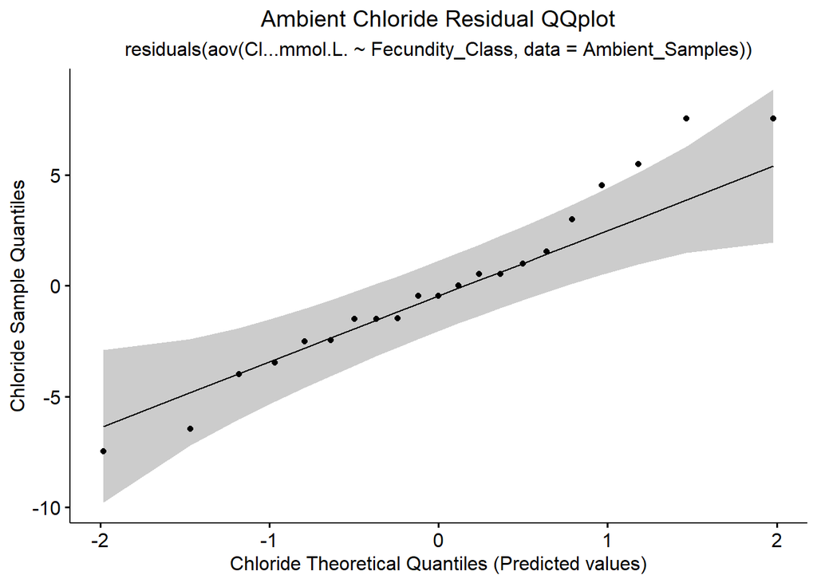

```r
# QQplot:
chloride_ambient_fec_res_qqplot <- ggqqplot(residuals(aov(Cl...mmol.L. ~ Fecundity_Class, data = Ambient_Samples))) +
labs(title = "Ambient Chloride Residual QQplot",
     subtitle = "residuals(aov(Cl...mmol.L. ~ Fecundity_Class, data = Ambient_Samples))",
                               x = "Chloride Theoretical Quantiles (Predicted values)",
                               y = "Chloride Sample Quantiles") +
  theme(plot.title = element_text(hjust = 0.5),
        plot.subtitle = element_text(hjust = 0.5))
print(chloride_ambient_fec_res_qqplot)
```

```r
# Parametric Variance test (Bartlett's test): require at least 2 obs for each group
bartlett.test(Cl...mmol.L. ~ Fecundity_Class, data = Ambient_Samples)
```

```
##
##  Bartlett test of homogeneity of variances
##
## data:  Cl...mmol.L. by Fecundity_Class
## Bartlett's K-squared = 0.82247, df = 2, p-value = 0.6628
```

```r
# Nonparametric variance test (Levene's test):
leveneTest(Cl...mmol.L. ~ Fecundity_Class, data = Ambient_Samples)
```

```
## Levene's Test for Homogeneity of Variance (center = median)
##       Df F value Pr(>F)
## group  2  0.5546 0.5838
##       18
```

```r
# Nonparametric stat test: Kruskall Wallis
kruskal.test(Cl...mmol.L. ~ Fecundity_Class, data = Ambient_Samples)
```

```
##
##  Kruskal-Wallis rank sum test
##
## data:  Cl...mmol.L. by Fecundity_Class
## Kruskal-Wallis chi-squared = 0.4005, df = 2, p-value = 0.8185
```

```r
# Nonparametric Post Hoc: Dunns
DunnettTest(Cl...mmol.L. ~ Fecundity_Class, data = Ambient_Samples)
```

```
##
##   Dunnett's test for comparing several treatments with a control :
##     95% family-wise confidence level
##
## $`High (>50,000)`
##                                    diff    lwr.ci   upr.ci   pval
## Low (~1,000s)-High (>50,000) -0.5000000 -7.613663 6.613663 0.9777
## Atresia-High (>50,000)        0.4615385 -5.290623 6.213700 0.9711
##
## ---
## Signif. codes:  0 '***' 0.001 '**' 0.01 '*' 0.05 '.' 0.1 ' ' 1
```

## Which fecundity class significantly different (if any)?

Parametric assumptions: - Normality (Shapiro-Wilk test): **Met** - Variance (Bartlett’s test): **Met**

Nonparametric variance test (Levene’s test): **Met**

Correlations: Parameter to Numerical Fecundity (without Atresia IDs)

```r
# Cl-
# Linear Model
chloride_amb_fec_no_atresia_lm <- lm(Cl...mmol.L. ~ Weight_Adjusted_Fecundity_Fecundity.Mean_Weight, data = Fecundity_No_Atresia_Samples)
summary(chloride_amb_fec_no_atresia_lm)
```

```
##
## Call:
## lm(formula = Cl...mmol.L. ~ Weight_Adjusted_Fecundity_Fecundity.Mean_Weight,
##     data = Fecundity_No_Atresia_Samples)
##
## Residuals:
##     Min      1Q  Median      3Q     Max
## -4.1972 -2.1453 -0.3044  2.3202  4.8677
##
## Coefficients:
##                                                  Estimate Std. Error t value
## (Intercept)                                     1.581e+02  2.042e+00  77.415
## Weight_Adjusted_Fecundity_Fecundity.Mean_Weight 7.028e-04  1.071e-02   0.066
##                                                 Pr(>|t|)
## (Intercept)                                     8.64e-13 ***
## Weight_Adjusted_Fecundity_Fecundity.Mean_Weight    0.949
## ---
## Signif. codes:  0 '***' 0.001 '**' 0.01 '*' 0.05 '.' 0.1 ' ' 1
##
## Residual standard error: 3.232 on 8 degrees of freedom
##   (18 observations deleted due to missingness)
## Multiple R-squared:  0.0005381,  Adjusted R-squared:  -0.1244
## F-statistic: 0.004307 on 1 and 8 DF,  p-value: 0.9493
```

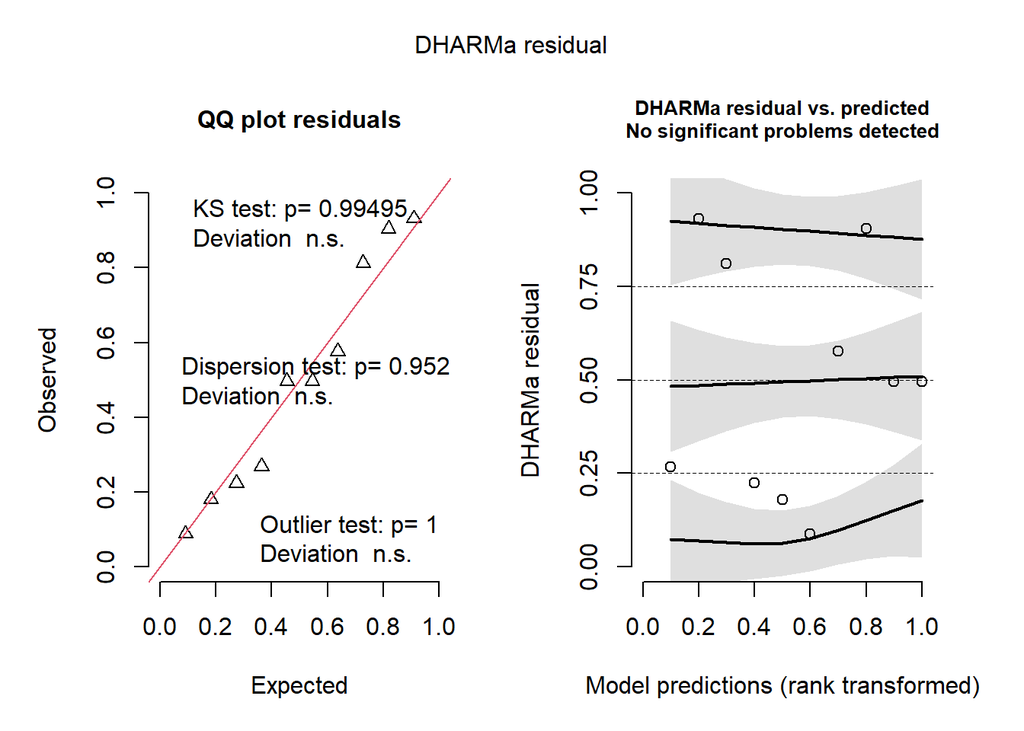

```r
chloride_ambient_sim <- simulateResiduals(fittedModel = chloride_amb_fec_no_atresia_lm)
plot(chloride_ambient_sim)
```

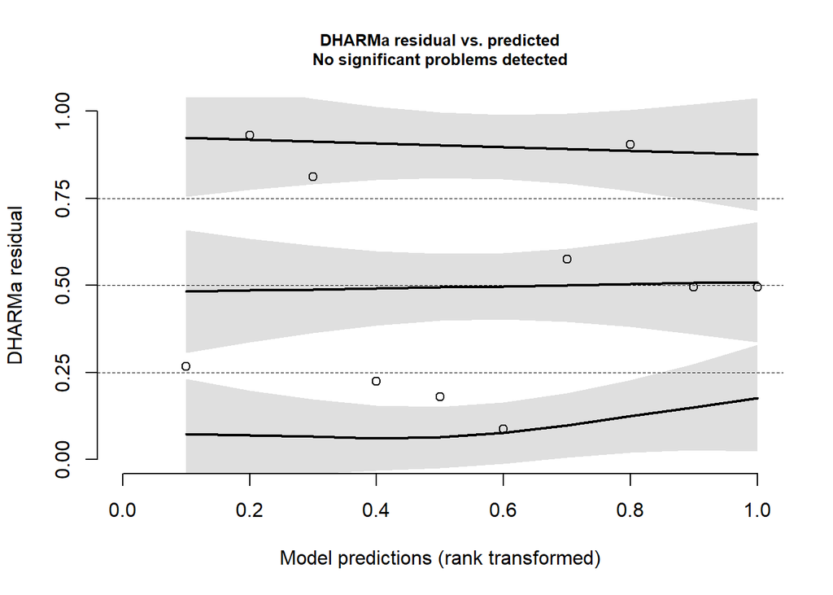

```r
plotResiduals(chloride_amb_fec_no_atresia_lm)
```

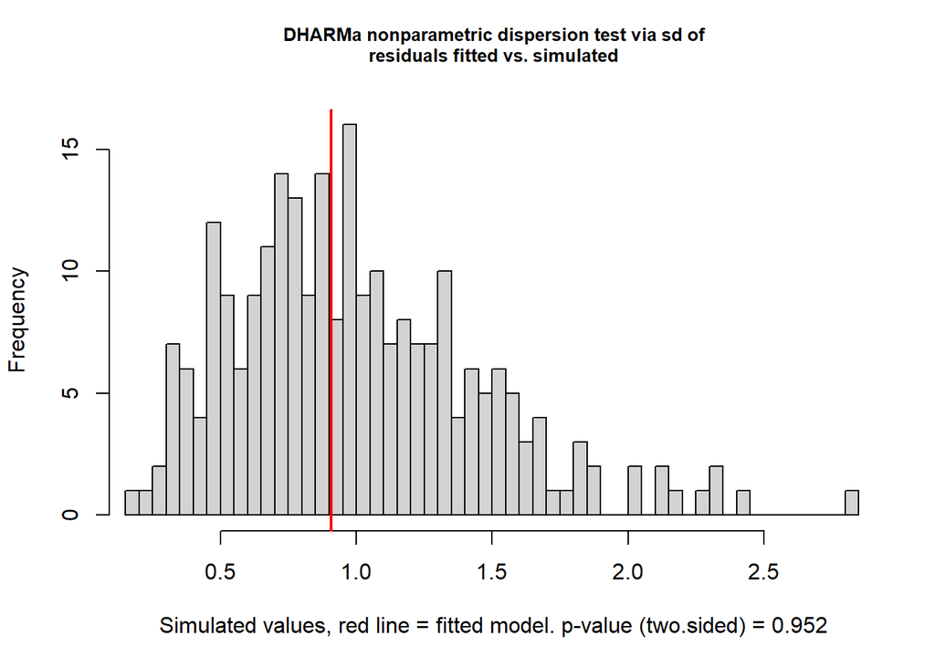

```
##
##  DHARMa nonparametric dispersion test via sd of residuals fitted vs.
##  simulated
##
## data:  simulationOutput
## dispersion = 0.90609, p-value = 0.952
## alternative hypothesis: two.sided
```

```r
testDispersion(chloride_amb_fec_no_atresia_lm)
```

```r
# Shapiro Test
shapiro.test(residuals(chloride_amb_fec_no_atresia_lm))
```

```
##
##  Shapiro-Wilk normality test
##
## data:  residuals(chloride_amb_fec_no_atresia_lm)
## W = 0.95118, p-value = 0.6824
```

```r
# Transform data: square root
chloride_ambient_sqrt <- Amb_Fec_No_Atresia_Samples %>%
  mutate(Cl...mmol.L. = sqrt(Cl...mmol.L.))

# Rerun lm model with square root transformed data
chloride_amb_fec_no_atresia_lm_sqrt <- lm(Cl...mmol.L. ~ Weight_Adjusted_Fecundity_Fecundity.Mean_Weight, data = chloride_ambient_sqrt)
summary(chloride_amb_fec_no_atresia_lm_sqrt)
```

```
##
## Call:
## lm(formula = Cl...mmol.L. ~ Weight_Adjusted_Fecundity_Fecundity.Mean_Weight,
##     data = chloride_ambient_sqrt)
##
## Residuals:
##      Min       1Q   Median       3Q      Max
## -0.14856 -0.08721 -0.02279  0.07258  0.20200
##
## Coefficients:
##                                                   Estimate Std. Error t value
## (Intercept)                                      1.257e+01  8.518e-02 147.566
## Weight_Adjusted_Fecundity_Fecundity.Mean_Weight -7.493e-05  4.852e-04  -0.154
##                                                 Pr(>|t|)
## (Intercept)                                     6.53e-12 ***
## Weight_Adjusted_Fecundity_Fecundity.Mean_Weight    0.882
## ---
## Signif. codes:  0 '***' 0.001 '**' 0.01 '*' 0.05 '.' 0.1 ' ' 1
##
## Residual standard error: 0.133 on 6 degrees of freedom
## Multiple R-squared:  0.003959,   Adjusted R-squared:  -0.162
## F-statistic: 0.02385 on 1 and 6 DF,  p-value: 0.8823
```

```
## qu = 0.75, log(sigma) = -2.939317 : outer Newton did not converge fully.
```

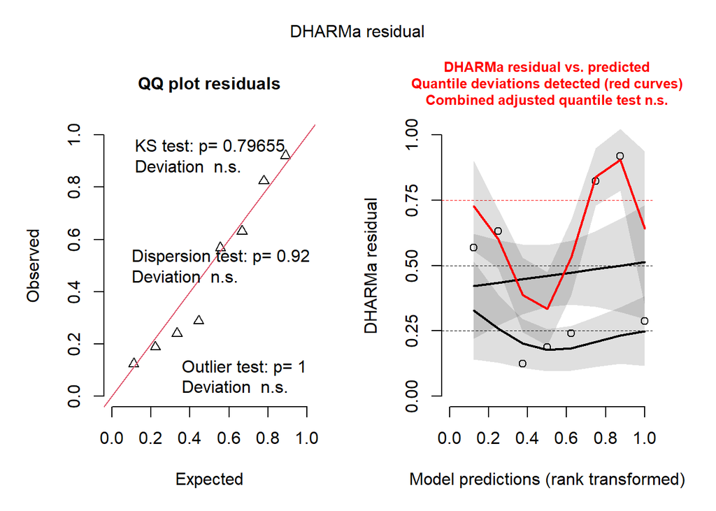

```r
chloride_amb_fec_sqrt_sim <- simulateResiduals(fittedModel = chloride_amb_fec_no_atresia_lm_sqrt)
plot(chloride_amb_fec_sqrt_sim)
```

```
## qu = 0.75, log(sigma) = -2.939317 : outer Newton did not converge fully.
```

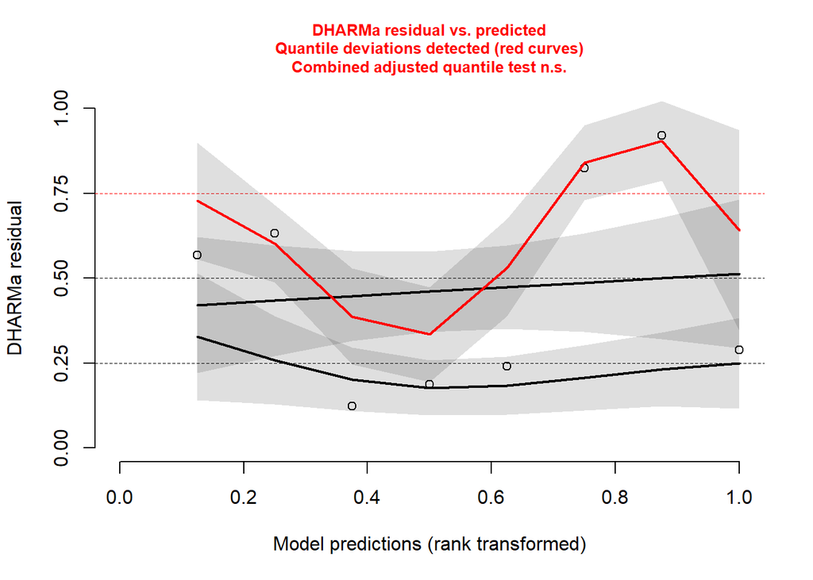

```r
plotResiduals(chloride_amb_fec_no_atresia_lm_sqrt)
```

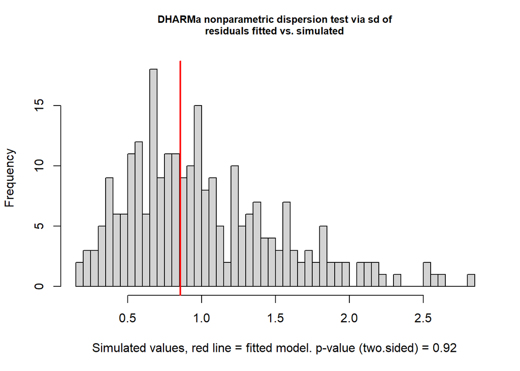

```
##
##  DHARMa nonparametric dispersion test via sd of residuals fitted vs.
##  simulated
##
## data:  simulationOutput
## dispersion = 0.84221, p-value = 0.92
## alternative hypothesis: two.sided
```

```r
testDispersion(chloride_amb_fec_no_atresia_lm_sqrt)
```

```r
# Residuals of model for shapiro test
chloride_amb_fec_no_atresia_lm_res <- residuals(chloride_amb_fec_no_atresia_lm_sqrt)

# Normality test
shapiro.test(chloride_amb_fec_no_atresia_lm_res)
```

```
##
##  Shapiro-Wilk normality test
##
## data:  chloride_amb_fec_no_atresia_lm_res
## W = 0.94043, p-value = 0.6153
```

```r
# Parametric variance test: bartlett's test
# Require at least 2 obs for each group
#bartlett.test(Cl...mmol.L. ~ Weight_Adjusted_Fecundity_Fecundity.Mean_Weight, data = chloride_ambient_sqrt)

# Nonparametric variance test (Levene's test)
# NA for quantitative explanatory variables
# leveneTest(Cl...mmol.L. ~ Weight_Adjusted_Fecundity_Fecundity.Mean_Weight, data = chloride_ambient_sqrt)
```

Chloride Ambient No Atresia Results

## Does a significant correlation exist between weight adj fecundity and parameter?

Parametric assumptions: - Normality (Shapiro-Wilk test): **Met** - Variance (Bartlett’s test): NA

Nonparametric variance test (Levene’s test): NA

Residuals Plot (if significant)

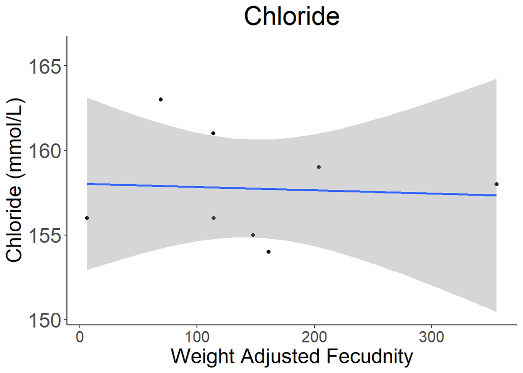

```r
# Cl-
# Ambient samples

# ggplot with geom_smooth(aes(x=,y=)), method = "lm")

chloride_ambient_lm_scatterplot <- ggplot(data = Ambient_Samples, aes(x = Weight_Adjusted_Fecundity_Fecundity.Mean_Weight, y = Cl...mmol.L.)) +
  geom_point() +
  geom_smooth(aes(group = 1), method = "lm") +
  labs(title = "Chloride", x = "Weight Adjusted Fecudnity", y = "Chloride (mmol/L)", color = "Category") +
  scale_y_continuous() +
  theme_classic() +
  theme(panel.background = element_rect(fill = "white"),
        plot.background = element_rect(fill = "white"),
        legend.background = element_rect(fill = "white", color = "black"),
        plot.title = element_text(size = 25, hjust = 0.5),
        axis.text.x = element_text(size = 15),
        axis.text.y = element_text(size = 20),
        axis.title.x = element_text(size = 20),
        axis.title.y = element_text(size = 20))

print(chloride_ambient_lm_scatterplot)
```

```r
ggsave(filename = "data-images/chloride_ambient_lm_scatterplot.pdf", plot = chloride_ambient_lm_scatterplot, device = "pdf")
ggsave(filename = "data-images/chloride_ambient_lm_scatterplot.png", plot = chloride_ambient_lm_scatterplot, device = "png")
```

# K+ : Potassium

Potassium Summary Stats

```r
# K+
# Summary stats

# Ambient data
Ambient_Samples %>%
  group_by(Ambient.Or.OAH, Consensus_Brood_Condition) %>%
  summarize(count = n(),
            median = round(median(K...mmol.L.), 3),
            mean = round(mean(K...mmol.L.), 3),
            sd = round(sd(K...mmol.L.), 3),
            cv = round(sd(K...mmol.L.)/mean(K...mmol.L.), 3)) %>%
  ungroup()
```

```
## # A tibble: 4 × 7
##   Ambient.Or.OAH Consensus_Brood_Condition count median  mean     sd     cv
##   <ord>          <ord>                     <int>  <dbl> <dbl>  <dbl>  <dbl>
## 1 Ambient        Excellent                     1    2.7  2.7  NA     NA
## 2 Ambient        Normal                        4    2.7  2.7   0.082  0.03
## 3 Ambient        Low                           3    2.7  2.73  0.252  0.092
## 4 Ambient        Atresia                      13    2.7  2.86  0.304  0.106
```

```r
Ambient_Samples %>%
  group_by(Ambient.Or.OAH, Fecundity_Class) %>%
  summarize(count = n(),
            median = round(median(K...mmol.L.), 3),
            mean = round(mean(K...mmol.L.), 3),
            sd = round(sd(K...mmol.L.), 3),
            cv = round(sd(K...mmol.L.)/mean(K...mmol.L.), 3)) %>%
  ungroup()
```

```
## # A tibble: 3 × 7
##   Ambient.Or.OAH Fecundity_Class count median  mean    sd    cv
##   <ord>          <ord>           <int>  <dbl> <dbl> <dbl> <dbl>
## 1 Ambient        High (>50,000)      4    2.7  2.7  0.082 0.03
## 2 Ambient        Low (~1,000s)       4    2.7  2.72 0.206 0.076
## 3 Ambient        Atresia            13    2.7  2.86 0.304 0.106
```

```r
Amb_Fec_No_Atresia_Samples %>%
  group_by(Ambient.Or.OAH, Fecundity_Class) %>%
  summarize(count = n(),
            median = round(median(K...mmol.L.), 3),
            mean = round(mean(K...mmol.L.), 3),
            sd = round(sd(K...mmol.L.), 3),
            cv = round(sd(K...mmol.L.)/mean(K...mmol.L.), 3)) %>%
  ungroup()
```

```
## # A tibble: 2 × 7
##   Ambient.Or.OAH Fecundity_Class count median  mean    sd    cv
##   <ord>          <ord>           <int>  <dbl> <dbl> <dbl> <dbl>
## 1 Ambient        High (>50,000)      4    2.7  2.7  0.082 0.03
## 2 Ambient        Low (~1,000s)       4    2.7  2.72 0.206 0.076
```

Potassium Boxplot

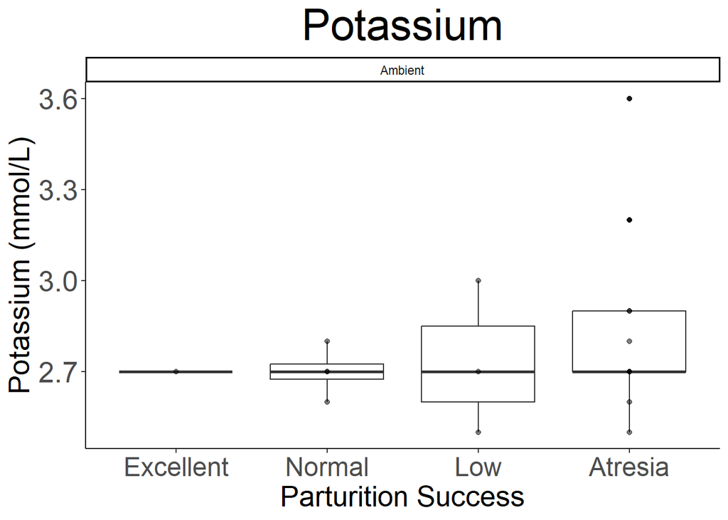

```r
# K+ boxplot

# Ambient Samples
potassium_ambient_boxplot <- ggplot(data = Ambient_Samples) +
  geom_boxplot(aes(x = Consensus_Brood_Condition, y = K...mmol.L.)) +
  geom_point(aes(x = Consensus_Brood_Condition, y = K...mmol.L.), alpha = 0.5, colour = "black") +
  labs(title = "Potassium", x = "Parturition Success", y = "Potassium (mmol/L)") +
  facet_wrap(~ Ambient.Or.OAH) +
  theme_classic() +
  theme(panel.background = element_rect(fill = "white"),
        plot.background = element_rect(fill = "white"),
        legend.background = element_rect(fill = "white", color = "black"),
        title = element_text(size = 12),
        plot.title = element_text(size = 30, hjust = 0.5),
        axis.text.x = element_text(size = 18),
        axis.text.y = element_text(size = 20),
        axis.title.x = element_text(size = 20),
        axis.title.y = element_text(size = 20))

print(potassium_ambient_boxplot)
```

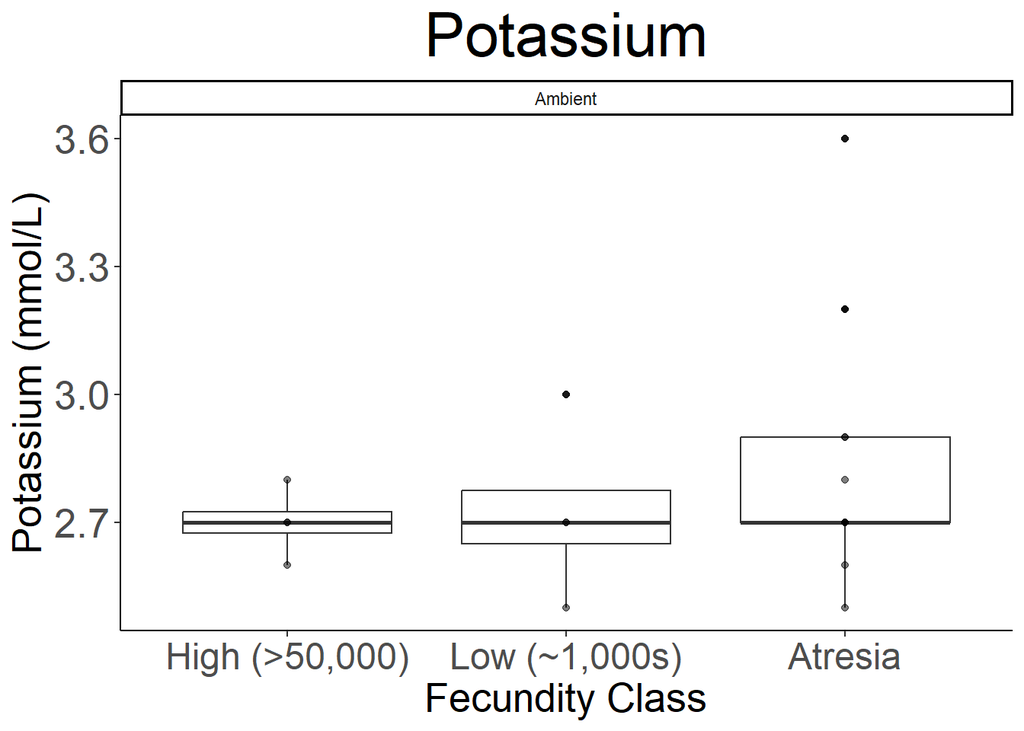

```r
ggsave(filename = "data-images/potassium_ambient_boxplot.pdf", plot = potassium_ambient_boxplot, device = "pdf")
ggsave(filename = "data-images/potassium_ambient_boxplot.png", plot = potassium_ambient_boxplot, device = "png")
potassium_ambient_fecundity_boxplot <- ggplot(data = Ambient_Samples) +
  geom_boxplot(aes(x = Fecundity_Class, y = K...mmol.L.)) +
  geom_point(aes(x = Fecundity_Class, y = K...mmol.L.), alpha = 0.5, colour = "black") +
  labs(title = "Potassium", x = "Fecundity Class", y = "Potassium (mmol/L)") +
  facet_wrap(~ Ambient.Or.OAH) +
  theme_classic() +
  theme(panel.background = element_rect(fill = "white"),
        plot.background = element_rect(fill = "white"),
        legend.background = element_rect(fill = "white", color = "black"),
        title = element_text(size = 12),
        plot.title = element_text(size = 30, hjust = 0.5),
        axis.text.x = element_text(size = 18),
        axis.text.y = element_text(size = 20),
        axis.title.x = element_text(size = 20),
        axis.title.y = element_text(size = 20))

print(potassium_ambient_fecundity_boxplot)
```

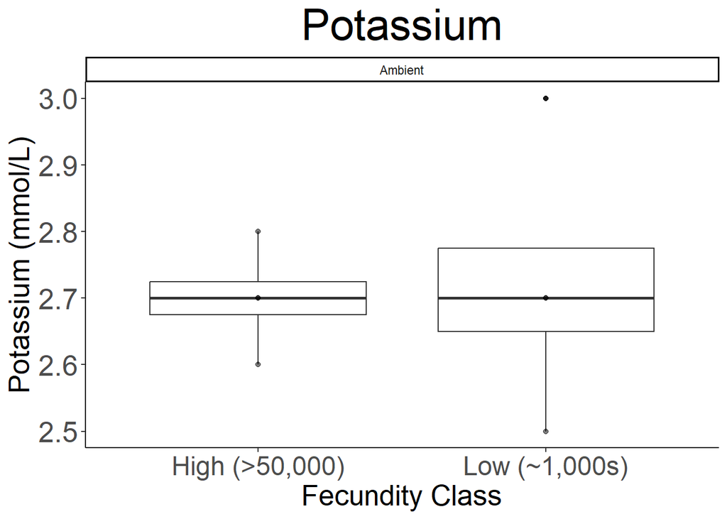

```r
ggsave(filename = "data-images/potassium_ambient_fecundity_boxplot.pdf", plot = potassium_ambient_fecundity_boxplot, device = "pdf")
ggsave(filename = "data-images/potassium_ambient_fecundity_boxplot.png", plot = potassium_ambient_fecundity_boxplot, device = "png")
potassium_amb_fec_no_atresia_boxplot <- ggplot(data = Amb_Fec_No_Atresia_Samples) +
  geom_boxplot(aes(x = Fecundity_Class, y = K...mmol.L.)) +
  geom_point(aes(x = Fecundity_Class, y = K...mmol.L.), alpha = 0.5, colour = "black") +
  labs(title = "Potassium", x = "Fecundity Class", y = "Potassium (mmol/L)") +
  facet_wrap(~ Ambient.Or.OAH) +
  theme_classic() +
  theme(panel.background = element_rect(fill = "white"),
        plot.background = element_rect(fill = "white"),
        legend.background = element_rect(fill = "white", color = "black"),
        title = element_text(size = 12),
        plot.title = element_text(size = 30, hjust = 0.5),
        axis.text.x = element_text(size = 18),
        axis.text.y = element_text(size = 20),
        axis.title.x = element_text(size = 20),
        axis.title.y = element_text(size = 20))

print(potassium_amb_fec_no_atresia_boxplot)
```

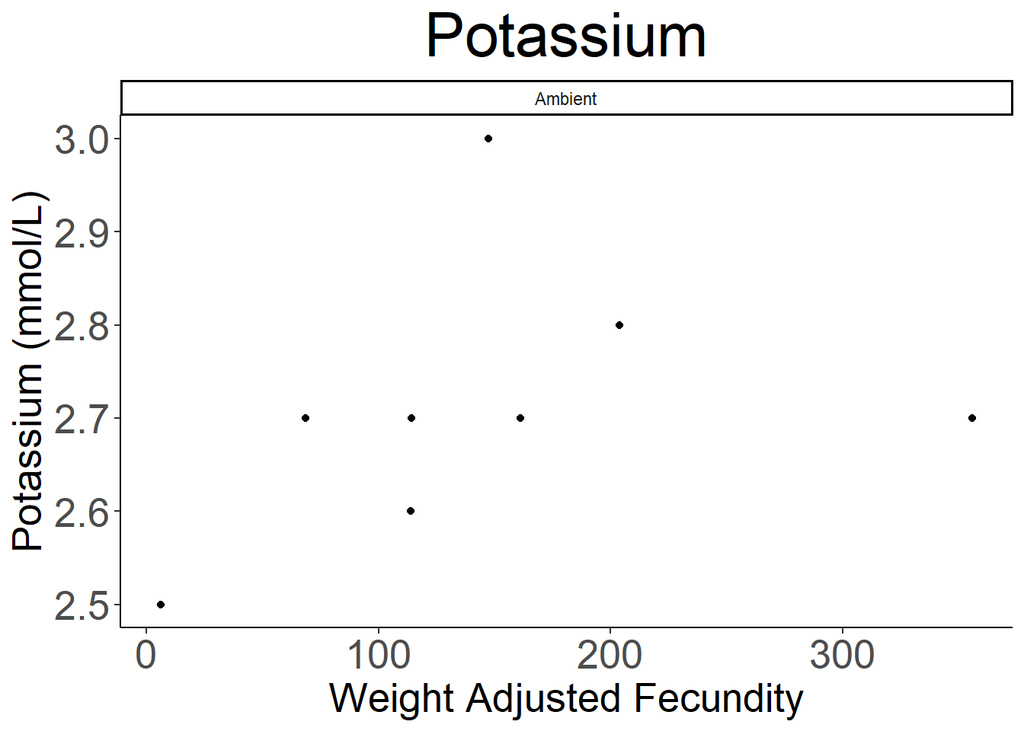

```r
ggsave(filename = "data-images/potassium_amb_fec_no_atresia_boxplot.pdf", plot = potassium_amb_fec_no_atresia_boxplot, device = "pdf")
ggsave(filename = "data-images/potassium_amb_fec_no_atresia_boxplot.png", plot = potassium_amb_fec_no_atresia_boxplot, device = "png")
potassium_amb_fec_no_atresia_scatterplot <- Amb_Fec_No_Atresia_Samples %>%
  ggplot() +
  geom_point(aes(x = Weight_Adjusted_Fecundity_Fecundity.Mean_Weight, y = K...mmol.L.), colour = "black") +
  labs(title = "Potassium", x = "Weight Adjusted Fecundity", y = "Potassium (mmol/L)") +
  facet_wrap(~ Ambient.Or.OAH) +
  theme_classic() +
  theme(panel.background = element_rect(fill = "white"),
        plot.background = element_rect(fill = "white"),
        legend.background = element_rect(fill = "white", color = "black"),
        title = element_text(size = 12),
        plot.title = element_text(size = 30, hjust = 0.5),
        axis.text.x = element_text(size = 20),
        axis.text.y = element_text(size = 20),
        axis.title.x = element_text(size = 20),
        axis.title.y = element_text(size = 20))

print(potassium_amb_fec_no_atresia_scatterplot)
```

```r
ggsave(filename = "data-images/potassium_amb_fec_no_atresia_scatterplot.pdf", plot = potassium_amb_fec_no_atresia_scatterplot, device = "pdf")
ggsave(filename = "data-images/potassium_amb_fec_no_atresia_scatterplot.pdf", plot = potassium_amb_fec_no_atresia_scatterplot, device = "png")
```

# K+ Stat Tests

Differences: Between Brood Condition

```r
# K+
# Ambient ANOVA Test

# Testing for differences in ambient parturition success metrics
# One-way ANOVA (parametric) or Kruskal-Wallis test (nonparametric)

potassium_aov_ambient_brood <- aov(K...mmol.L. ~ Consensus_Brood_Condition, data = Ambient_Samples)
summary(potassium_aov_ambient_brood)
```

```
##                           Df Sum Sq Mean Sq F value Pr(>F)
## Consensus_Brood_Condition  3 0.1121 0.03736   0.505  0.684
## Residuals                 17 1.2574 0.07397
```

```r
# If significant, Post Hoc Test:
# - Tukey's HSD (parametric, normality & equal variance across groups)
# - Dunn's test (non-parametric, after Kruskal-Wallis test)

TukeyHSD(potassium_aov_ambient_brood)
```

```
##   Tukey multiple comparisons of means
##     95% family-wise confidence level
##
## Fit: aov(formula = K...mmol.L. ~ Consensus_Brood_Condition, data = Ambient_Samples)
##
## $Consensus_Brood_Condition
##                         diff        lwr       upr     p adj
## Normal-Excellent  0.00000000 -0.8643366 0.8643366 1.0000000
## Low-Excellent     0.03333333 -0.8593496 0.9260163 0.9995541
## Atresia-Excellent 0.16153846 -0.6407309 0.9638078 0.9389808
## Low-Normal        0.03333333 -0.5571209 0.6237876 0.9984688
## Atresia-Normal    0.16153846 -0.2804904 0.6035674 0.7296107
## Atresia-Low       0.12820513 -0.3669663 0.6233765 0.8812696
```

```r
# Parametric tests

# Normality
shapiro.test(Ambient_Samples$K...mmol.L.)
```

```
##
##  Shapiro-Wilk normality test
##
## data:  Ambient_Samples$K...mmol.L.
## W = 0.81347, p-value = 0.001062
```

```r
shapiro.test(residuals(aov(K...mmol.L. ~ Consensus_Brood_Condition, data = Ambient_Samples)))
```

```
##
##  Shapiro-Wilk normality test
##
## data:  residuals(aov(K...mmol.L. ~ Consensus_Brood_Condition, data = Ambient_Samples))
## W = 0.886, p-value = 0.0189
```

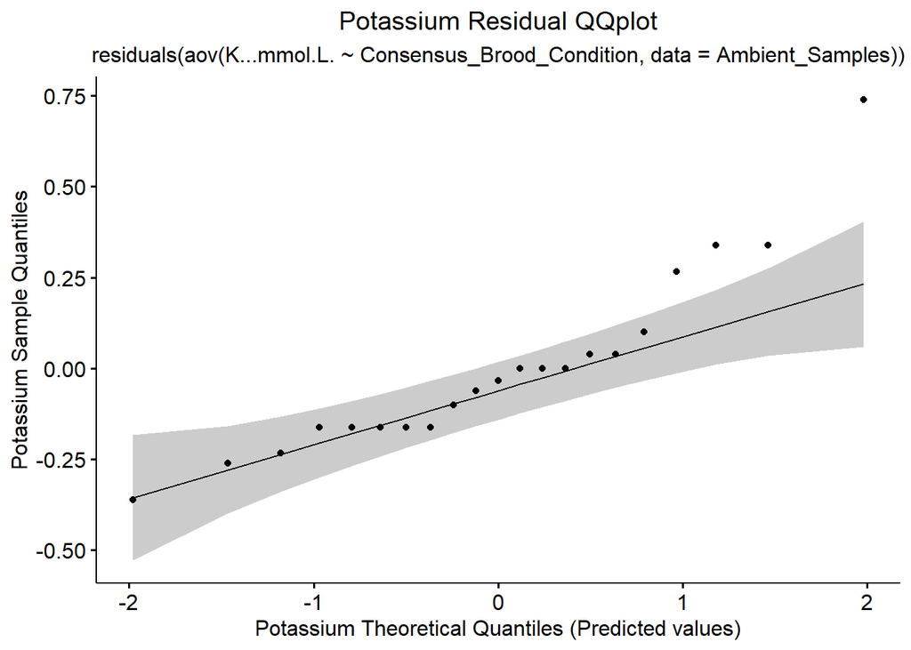

```r
# QQplot:
potassium_ambient_res_qqplot <- ggqqplot(residuals(aov(K...mmol.L. ~ Consensus_Brood_Condition, data = Ambient_Samples))) +
labs(title = "Potassium Residual QQplot",
     subtitle = "residuals(aov(K...mmol.L. ~ Consensus_Brood_Condition, data = Ambient_Samples))",
                               x = "Potassium Theoretical Quantiles (Predicted values)",
                               y = "Potassium Sample Quantiles") +
  theme(plot.title = element_text(hjust = 0.5),
        plot.subtitle = element_text(hjust = 0.5))
print(potassium_ambient_res_qqplot)
```

```r
# Parametric Variance test (Bartlett's test): require at least 2 obs for each group
# bartlett.test(K...mmol.L. ~ Consensus_Brood_Condition, data = Ambient_Samples)

# Nonparametric variance test (Levene's test):
leveneTest(K...mmol.L. ~ Consensus_Brood_Condition, data = Ambient_Samples)
```

```
## Levene's Test for Homogeneity of Variance (center = median)
##       Df F value Pr(>F)
## group  3  0.6208 0.6111
##       17
```

```r
# Nonparametric stat test: Kruskall Wallis
kruskal.test(K...mmol.L. ~ Consensus_Brood_Condition, data = Ambient_Samples)
```

```
##
##  Kruskal-Wallis rank sum test
##
## data:  K...mmol.L. by Consensus_Brood_Condition
## Kruskal-Wallis chi-squared = 1.2134, df = 3, p-value = 0.7498
```

```r
# Nonparametric Post Hoc: Dunn's test
DunnTest(K...mmol.L. ~ Consensus_Brood_Condition, data = Ambient_Samples)
```

```
##
##  Dunn's test of multiple comparisons using rank sums : holm
##
##                   mean.rank.diff   pval
## Normal-Excellent        0.000000 1.0000
## Low-Excellent           0.500000 1.0000
## Atresia-Excellent       3.115385 1.0000
## Low-Normal              0.500000 1.0000
## Atresia-Normal          3.115385 1.0000
## Atresia-Low             2.615385 1.0000
## ---
## Signif. codes:  0 '***' 0.001 '**' 0.01 '*' 0.05 '.' 0.1 ' ' 1
```

Potassium Ambient Results

## Which brood condition significantly different (if any)?

Parametric assumptions: - Normality (Shapiro-Wilk test): **Not Met** - Variance (Bartletts test): NA

- Nonparametric variance (Levene’s test): **Met**
- Nonparametric Post Hoc: Dunn’s Test

Differences: Between Fecundity Class

```r
# K+
# Ambient ANOVA Test

# Testing for differences in ambient parturition success metrics
# One-way ANOVA (parametric) or Kruskal-Wallis test (nonparametric)

potassium_aov_ambient_fec <- aov(K...mmol.L. ~ Fecundity_Class, data = Ambient_Samples)
summary(potassium_aov_ambient_fec)
```

```
##                 Df Sum Sq Mean Sq F value Pr(>F)
## Fecundity_Class  2 0.1113 0.05563   0.796  0.466
## Residuals       18 1.2583 0.06990
```

```r
# If significant, Post Hoc Test:
# - Tukey's HSD (parametric, normality & equal variance across groups)
# - Dunn's test (non-parametric, after Kruskal-Wallis test)

TukeyHSD(potassium_aov_ambient_fec)
```

```
##   Tukey multiple comparisons of means
##     95% family-wise confidence level
##
## Fit: aov(formula = K...mmol.L. ~ Fecundity_Class, data = Ambient_Samples)
##
## $Fecundity_Class
##                                   diff        lwr       upr     p adj
## Low (~1,000s)-High (>50,000) 0.0250000 -0.4521380 0.5021380 0.9901955
## Atresia-High (>50,000)       0.1615385 -0.2242789 0.5473558 0.5449631
## Atresia-Low (~1,000s)        0.1365385 -0.2492789 0.5223558 0.6452587
```

```r
# Parametric tests

# Normality
shapiro.test(Ambient_Samples$K...mmol.L.)
```

```
##
##  Shapiro-Wilk normality test
##
## data:  Ambient_Samples$K...mmol.L.
## W = 0.81347, p-value = 0.001062
```

```r
shapiro.test(residuals(aov(K...mmol.L. ~ Fecundity_Class, data = Ambient_Samples)))
```

```
##
##  Shapiro-Wilk normality test
##
## data:  residuals(aov(K...mmol.L. ~ Fecundity_Class, data = Ambient_Samples))
## W = 0.88368, p-value = 0.0171
```

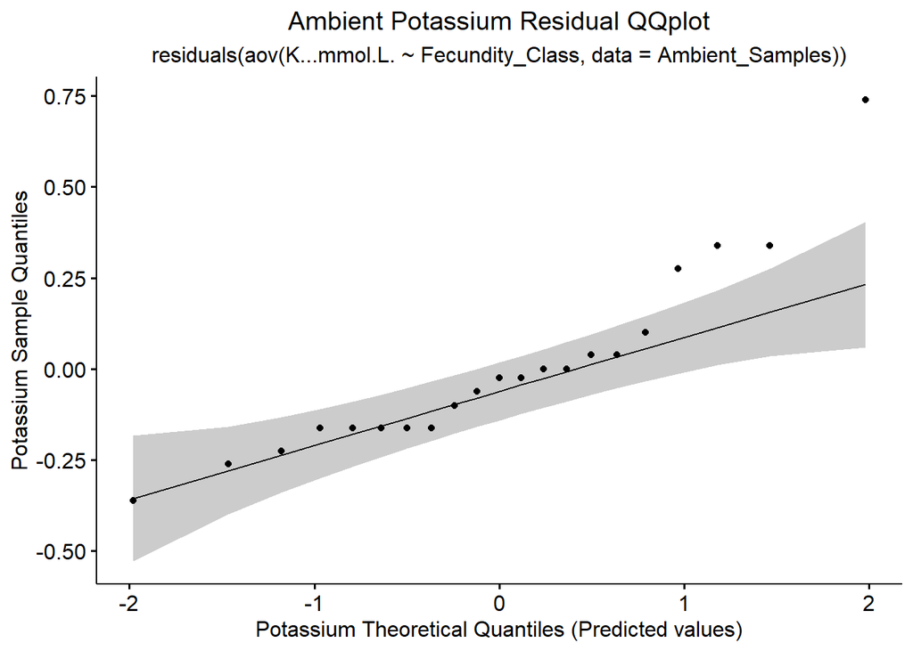

```r
# QQplot:
potassium_ambient_fec_res_qqplot <- ggqqplot(residuals(aov(K...mmol.L. ~ Fecundity_Class, data = Ambient_Samples))) +
labs(title = "Ambient Potassium Residual QQplot",
     subtitle = "residuals(aov(K...mmol.L. ~ Fecundity_Class, data = Ambient_Samples))",
                               x = "Potassium Theoretical Quantiles (Predicted values)",
                               y = "Potassium Sample Quantiles") +
  theme(plot.title = element_text(hjust = 0.5),
        plot.subtitle = element_text(hjust = 0.5))
print(potassium_ambient_fec_res_qqplot)
```

```r
# Parametric Variance test (Bartlett's test): require at least 2 obs for each group
bartlett.test(K...mmol.L. ~ Fecundity_Class, data = Ambient_Samples)
```

```
##
##  Bartlett test of homogeneity of variances
##
## data:  K...mmol.L. by Fecundity_Class
## Bartlett's K-squared = 4.6368, df = 2, p-value = 0.09843
```

```r
# Nonparametric variance test (Levene's test):
leveneTest(K...mmol.L. ~ Fecundity_Class, data = Ambient_Samples)
```

```
## Levene's Test for Homogeneity of Variance (center = median)
##       Df F value Pr(>F)
## group  2  0.7708 0.4773
##       18
```

```r
# Nonparametric stat test: Kruskall Wallis
kruskal.test(K...mmol.L. ~ Fecundity_Class, data = Ambient_Samples)
```

```
##
##  Kruskal-Wallis rank sum test
##
## data:  K...mmol.L. by Fecundity_Class
## Kruskal-Wallis chi-squared = 1.2081, df = 2, p-value = 0.5466
```

```r
# Nonparametric stat test: Kruskall Wallis
kruskal.test(K...mmol.L. ~ Fecundity_Class, data = Ambient_Samples)
```

```
##
##  Kruskal-Wallis rank sum test
##
## data:  K...mmol.L. by Fecundity_Class
## Kruskal-Wallis chi-squared = 1.2081, df = 2, p-value = 0.5466
```

```r
# Nonparametric Post Hoc: Dunns test
DunnettTest(K...mmol.L. ~ Fecundity_Class, data = Ambient_Samples)
```

```
##
##   Dunnett's test for comparing several treatments with a control :
##     95% family-wise confidence level
##
## $`High (>50,000)`
##                                   diff     lwr.ci    upr.ci   pval
## Low (~1,000s)-High (>50,000) 0.0250000 -0.4195254 0.4695254 0.9857
## Atresia-High (>50,000)       0.1615385 -0.1979081 0.5209850 0.4550
##
## ---
## Signif. codes:  0 '***' 0.001 '**' 0.01 '*' 0.05 '.' 0.1 ' ' 1
```

Potassium Ambient Results

## Which fecundity class significantly different (if any)?

Parametric assumptions: - Normality (Shapiro-Wilk test): **Not Met** - Variance (Bartlett’s test): **Kinda Met**

Nonparametric variance test (Levene’s test): **Met**

Correlations: Parameter to Numerical Fecundity (without Atresia IDs)

```r
# K+
# Linear Model
potassium_amb_fec_no_atresia_lm <- lm(K...mmol.L. ~ Weight_Adjusted_Fecundity_Fecundity.Mean_Weight, data = Fecundity_No_Atresia_Samples)
summary(potassium_amb_fec_no_atresia_lm)
```

```
##
## Call:
## lm(formula = K...mmol.L. ~ Weight_Adjusted_Fecundity_Fecundity.Mean_Weight,
##     data = Fecundity_No_Atresia_Samples)
##
## Residuals:
##      Min       1Q   Median       3Q      Max
## -0.21166 -0.11568 -0.04065  0.00147  0.39801
##
## Coefficients:
##                                                  Estimate Std. Error t value
## (Intercept)                                     2.6473078  0.1245207  21.260
## Weight_Adjusted_Fecundity_Fecundity.Mean_Weight 0.0007432  0.0006530   1.138
##                                                 Pr(>|t|)
## (Intercept)                                     2.52e-08 ***
## Weight_Adjusted_Fecundity_Fecundity.Mean_Weight    0.288
## ---
## Signif. codes:  0 '***' 0.001 '**' 0.01 '*' 0.05 '.' 0.1 ' ' 1
##
## Residual standard error: 0.1971 on 8 degrees of freedom
##   (18 observations deleted due to missingness)
## Multiple R-squared:  0.1393, Adjusted R-squared:  0.03177
## F-statistic: 1.295 on 1 and 8 DF,  p-value: 0.288
```

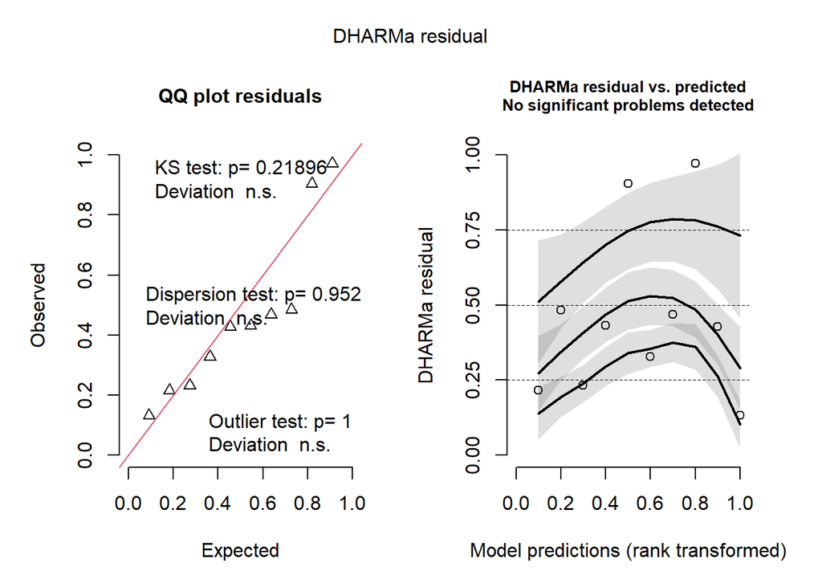

```r
potassium_ambient_sim <- simulateResiduals(fittedModel = potassium_amb_fec_no_atresia_lm)
plot(potassium_ambient_sim)
```

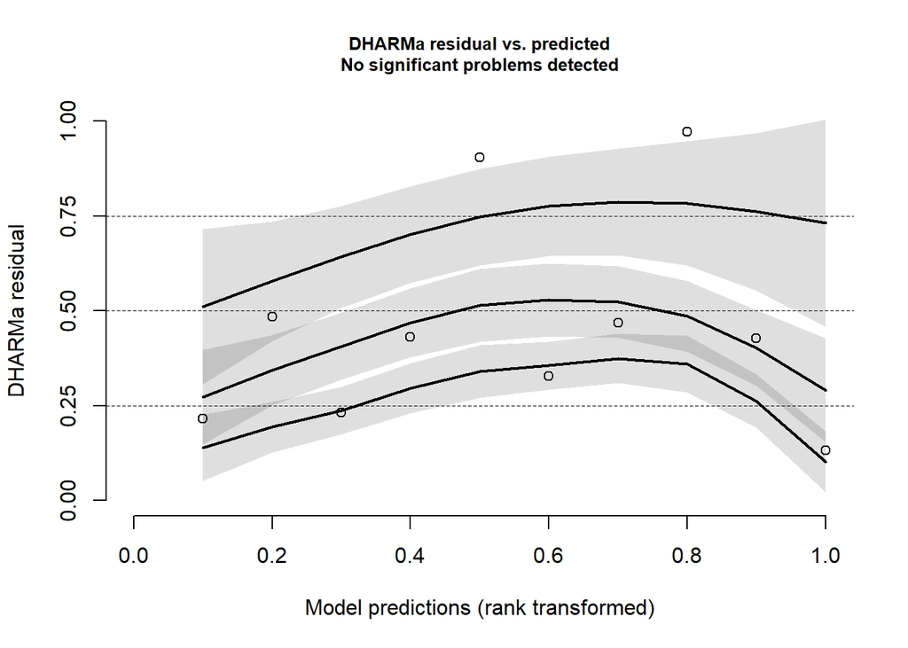

```r
plotResiduals(potassium_amb_fec_no_atresia_lm)
```

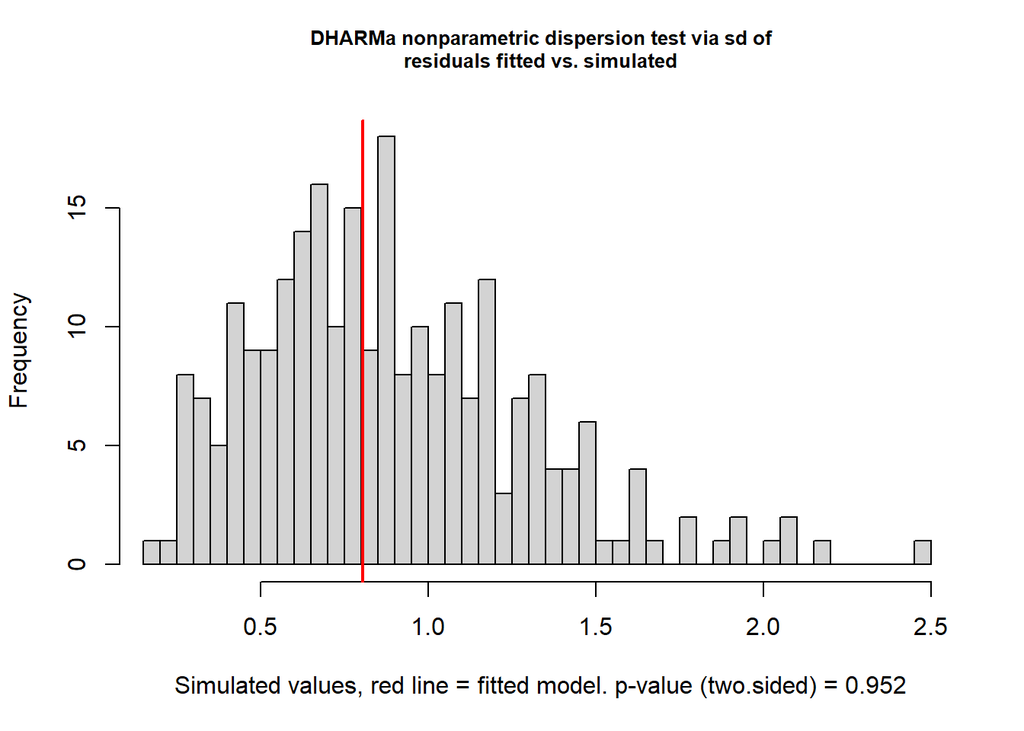

```
##
##  DHARMa nonparametric dispersion test via sd of residuals fitted vs.
##  simulated
##
## data:  simulationOutput
## dispersion = 0.90609, p-value = 0.952
## alternative hypothesis: two.sided
```

```r
testDispersion(potassium_amb_fec_no_atresia_lm)
```

```r
# Shapiro Test
shapiro.test(residuals(potassium_amb_fec_no_atresia_lm))
```

```
##
##  Shapiro-Wilk normality test
##
## data:  residuals(potassium_amb_fec_no_atresia_lm)
## W = 0.86151, p-value = 0.0795
```

```r
# Transform data: square root
potassium_ambient_sqrt <- Amb_Fec_No_Atresia_Samples %>%
  mutate(K...mmol.L. = sqrt(K...mmol.L.))

# Rerun lm model with square root transformed data
potassium_amb_fec_no_atresia_lm_sqrt <- lm(K...mmol.L. ~ Weight_Adjusted_Fecundity_Fecundity.Mean_Weight, data = potassium_ambient_sqrt)
summary(potassium_amb_fec_no_atresia_lm_sqrt)
```

```
##
## Call:
## lm(formula = K...mmol.L. ~ Weight_Adjusted_Fecundity_Fecundity.Mean_Weight,
##     data = potassium_ambient_sqrt)
##
## Residuals:
##       Min        1Q    Median        3Q       Max
## -0.043790 -0.030608 -0.001939  0.010984  0.085420
##
## Coefficients:
##                                                  Estimate Std. Error t value
## (Intercept)                                     1.6239747  0.0283420  57.299
## Weight_Adjusted_Fecundity_Fecundity.Mean_Weight 0.0001535  0.0001614   0.951
##                                                 Pr(>|t|)
## (Intercept)                                      1.9e-09 ***
## Weight_Adjusted_Fecundity_Fecundity.Mean_Weight    0.378
## ---
## Signif. codes:  0 '***' 0.001 '**' 0.01 '*' 0.05 '.' 0.1 ' ' 1
##
## Residual standard error: 0.04424 on 6 degrees of freedom
## Multiple R-squared:  0.131,  Adjusted R-squared:  -0.01382
## F-statistic: 0.9046 on 1 and 6 DF,  p-value: 0.3783
```

```
##
##  DHARMa: qgam was unable to calculate quantile regression for quantile 0.25. Possibly to few (unique) data points / predictions. The quantile will be ommited in plots and significance calculations.
```

```
##
##  DHARMa: qgam was unable to calculate quantile regression for quantile 0.5. Possibly to few (unique) data points / predictions. The quantile will be ommited in plots and significance calculations.
```

```
## qu = 0.75, log(sigma) = -3.903504 : outer Newton did not converge fully.
```

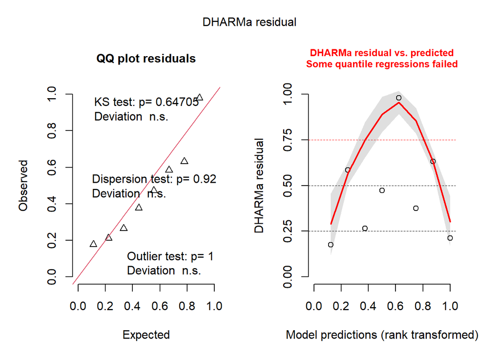

```r
potassium_amb_fec_sqrt_sim <- simulateResiduals(fittedModel = potassium_amb_fec_no_atresia_lm_sqrt)
plot(potassium_amb_fec_sqrt_sim)
```

```
##
##  DHARMa: qgam was unable to calculate quantile regression for quantile 0.25. Possibly to few (unique) data points / predictions. The quantile will be ommited in plots and significance calculations.
```

```
##
##  DHARMa: qgam was unable to calculate quantile regression for quantile 0.5. Possibly to few (unique) data points / predictions. The quantile will be ommited in plots and significance calculations.
```

```
## qu = 0.75, log(sigma) = -3.903504 : outer Newton did not converge fully.
```

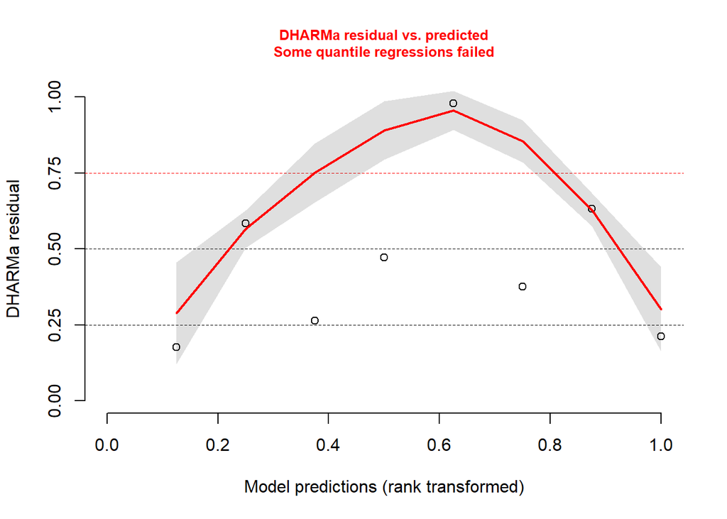

```r
plotResiduals(potassium_amb_fec_no_atresia_lm_sqrt)
```

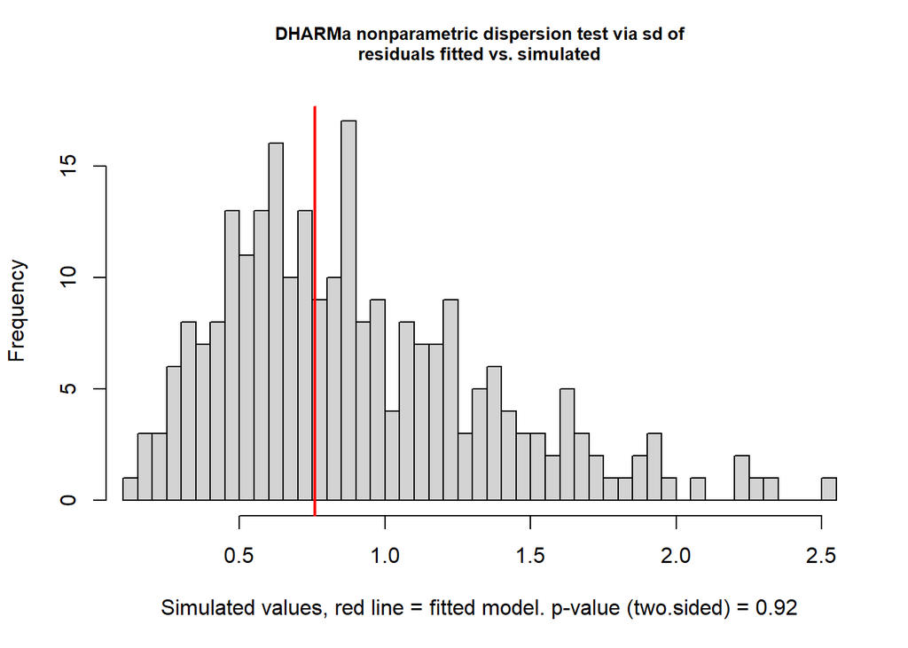

```
##
##  DHARMa nonparametric dispersion test via sd of residuals fitted vs.
##  simulated
##
## data:  simulationOutput
## dispersion = 0.84221, p-value = 0.92
## alternative hypothesis: two.sided
```

```r
testDispersion(potassium_amb_fec_no_atresia_lm_sqrt)
```

```r
# Residuals of model for shapiro test
potassium_amb_fec_no_atresia_lm_res <- residuals(potassium_amb_fec_no_atresia_lm_sqrt)

# Normality test
shapiro.test(potassium_amb_fec_no_atresia_lm_res)
```

```
##
##  Shapiro-Wilk normality test
##
## data:  potassium_amb_fec_no_atresia_lm_res
## W = 0.88746, p-value = 0.2216
```

```r
# Parametric variance test: bartlett's test
# Require at least 2 obs for each group
# bartlett.test(K...mmol.L. ~ Weight_Adjusted_Fecundity_Fecundity.Mean_Weight, data = potassium_ambient_sqrt)

# Nonparametric variance test (Levene's test)
# NA for quantitative explanatory variables
# leveneTest(K...mmol.L. ~ Weight_Adjusted_Fecundity_Fecundity.Mean_Weight, data = potassium_ambient_sqrt)
```

Potassium Ambient No Atresia Results

## Does a significant correlation exist between weight adj fecundity and parameter?

Parametric assumptions: - Normality (Shapiro-Wilk test): **Kinda Met** - Variance (Bartlett’s test): NA

Nonparametric variance test (Levene’s test): NA

Residuals Plot (if significant)

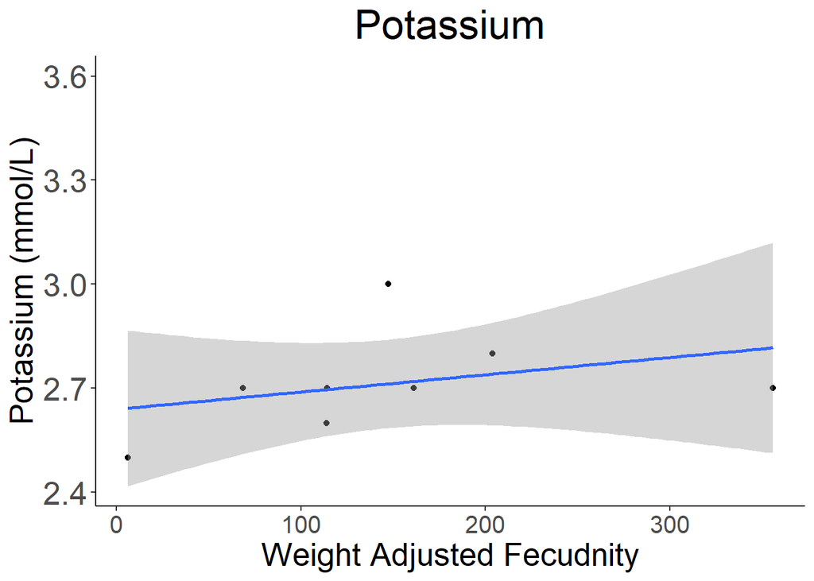

```r
# K+
# Ambient samples

# ggplot with geom_smooth(aes(x=,y=)), method = "lm")

potassium_ambient_lm_scatterplot <- ggplot(data = Ambient_Samples, aes(x = Weight_Adjusted_Fecundity_Fecundity.Mean_Weight, y = K...mmol.L.)) +
  geom_point() +
  geom_smooth(aes(group = 1), method = "lm") +
  labs(title = "Potassium", x = "Weight Adjusted Fecudnity", y = "Potassium (mmol/L)", color = "Category") +
  scale_y_continuous() +
  theme_classic() +
  theme(panel.background = element_rect(fill = "white"),
        plot.background = element_rect(fill = "white"),
        legend.background = element_rect(fill = "white", color = "black"),
        plot.title = element_text(size = 25, hjust = 0.5),
        axis.text.x = element_text(size = 15),
        axis.text.y = element_text(size = 20),
        axis.title.x = element_text(size = 20),
        axis.title.y = element_text(size = 20))

print(potassium_ambient_lm_scatterplot)
```

```r
ggsave(filename = "data-images/potassium_ambient_lm_scatterplot.pdf", plot = potassium_ambient_lm_scatterplot, device = "pdf")
ggsave(filename = "data-images/potassium_ambient_lm_scatterplot.png", plot = potassium_ambient_lm_scatterplot, device = "png")
```

# Ca+2 : Calcium

Calcium Summary Stats

```r
# Ca+2
# Summary stats

# Ambient data
Ambient_Samples %>%
  group_by(Ambient.Or.OAH, Consensus_Brood_Condition) %>%
  summarize(count = n(),
            median = round(median(Ca....mmol.L.), 3),
            mean = round(mean(Ca....mmol.L.), 3),
            sd = round(sd(Ca....mmol.L.), 3),
            cv = round(sd(Ca....mmol.L.)/mean(Ca....mmol.L.), 3)) %>%
  ungroup()
```

```
## # A tibble: 4 × 7
##   Ambient.Or.OAH Consensus_Brood_Condition count median  mean     sd     cv
##   <ord>          <ord>                     <int>  <dbl> <dbl>  <dbl>  <dbl>
## 1 Ambient        Excellent                     1   1.47  1.47 NA     NA
## 2 Ambient        Normal                        4   1.42  1.43  0.05   0.035
## 3 Ambient        Low                           3   1.43  1.42  0.036  0.025
## 4 Ambient        Atresia                      13   1.24  1.27  0.114  0.09
```

```r
Ambient_Samples %>%
  group_by(Ambient.Or.OAH, Fecundity_Class) %>%
  summarize(count = n(),
            median = round(median(Ca....mmol.L.), 3),
            mean = round(mean(Ca....mmol.L.), 3),
            sd = round(sd(Ca....mmol.L.), 3),
            cv = round(sd(Ca....mmol.L.)/mean(Ca....mmol.L.), 3)) %>%
  ungroup()
```

```
## # A tibble: 3 × 7
##   Ambient.Or.OAH Fecundity_Class count median  mean    sd    cv
##   <ord>          <ord>           <int>  <dbl> <dbl> <dbl> <dbl>
## 1 Ambient        High (>50,000)      4   1.45  1.45 0.044 0.03
## 2 Ambient        Low (~1,000s)       4   1.41  1.41 0.033 0.023
## 3 Ambient        Atresia            13   1.24  1.27 0.114 0.09
```

```r
Amb_Fec_No_Atresia_Samples %>%
  group_by(Ambient.Or.OAH, Fecundity_Class) %>%
  summarize(count = n(),
            median = round(median(Ca....mmol.L.), 3),
            mean = round(mean(Ca....mmol.L.), 3),
            sd = round(sd(Ca....mmol.L.), 3),
            cv = round(sd(Ca....mmol.L.)/mean(Ca....mmol.L.), 3)) %>%
  ungroup()
```

```
## # A tibble: 2 × 7
##   Ambient.Or.OAH Fecundity_Class count median  mean    sd    cv
##   <ord>          <ord>           <int>  <dbl> <dbl> <dbl> <dbl>
## 1 Ambient        High (>50,000)      4   1.45  1.45 0.044 0.03
## 2 Ambient        Low (~1,000s)       4   1.41  1.41 0.033 0.023
```

Calcium Boxplot

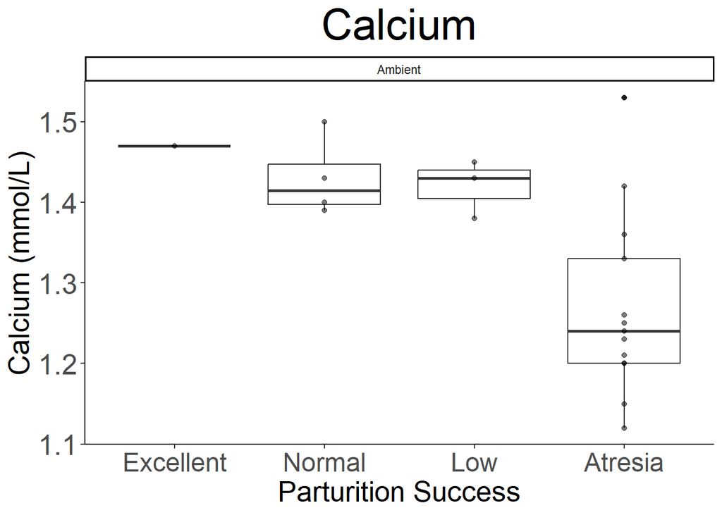

```r
# Ca+2 boxplot

# Ambient Samples
calcium_ambient_boxplot <- ggplot(data = Ambient_Samples) +
  geom_boxplot(aes(x = Consensus_Brood_Condition, y = Ca....mmol.L.)) +
  geom_point(aes(x = Consensus_Brood_Condition, y = Ca....mmol.L.), alpha = 0.5, colour = "black") +
  labs(title = "Calcium", x = "Parturition Success", y = "Calcium (mmol/L)") +
  facet_wrap(~ Ambient.Or.OAH) +
  theme_classic() +
  theme(panel.background = element_rect(fill = "white"),
        plot.background = element_rect(fill = "white"),
        legend.background = element_rect(fill = "white", color = "black"),
        title = element_text(size = 12),
        plot.title = element_text(size = 30, hjust = 0.5),
        axis.text.x = element_text(size = 18),
        axis.text.y = element_text(size = 20),
        axis.title.x = element_text(size = 20),
        axis.title.y = element_text(size = 20))

print(calcium_ambient_boxplot)
```

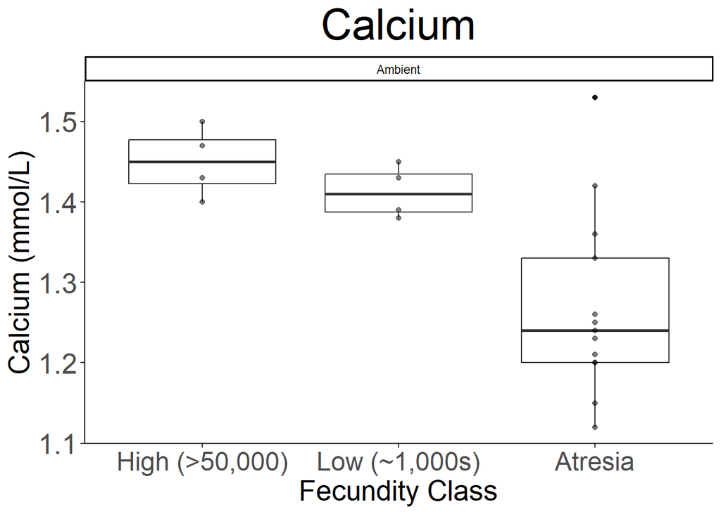

```r
ggsave(filename = "data-images/calcium_ambient_boxplot.pdf", plot = calcium_ambient_boxplot, device = "pdf")
ggsave(filename = "data-images/calcium_ambient_boxplot.png", plot = calcium_ambient_boxplot, device = "png")
calcium_ambient_fecundity_boxplot <- ggplot(data = Ambient_Samples) +
  geom_boxplot(aes(x = Fecundity_Class, y = Ca....mmol.L.)) +
  geom_point(aes(x = Fecundity_Class, y = Ca....mmol.L.), alpha = 0.5, colour = "black") +
  labs(title = "Calcium", x = "Fecundity Class", y = "Calcium (mmol/L)") +
  facet_wrap(~ Ambient.Or.OAH) +
  theme_classic() +
  theme(panel.background = element_rect(fill = "white"),
        plot.background = element_rect(fill = "white"),
        legend.background = element_rect(fill = "white", color = "black"),
        title = element_text(size = 12),
        plot.title = element_text(size = 30, hjust = 0.5),
        axis.text.x = element_text(size = 18),
        axis.text.y = element_text(size = 20),
        axis.title.x = element_text(size = 20),
        axis.title.y = element_text(size = 20))

print(calcium_ambient_fecundity_boxplot)
```